# Homework of all time

SA24204146

2024-12-08

# HW 0-th

## Example 1: Scatter Plot with Regression Line and Mathematical Formula

We are fitting a simple linear regression model to show the relationship between `mpg` and `wt` from the `mtcars` dataset.

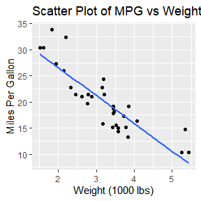

```r
library(ggplot2)
ggplot(mtcars, aes(x=wt, y=mpg)) +
  geom_point() +
  geom_smooth(method="lm", se=FALSE) +
  labs(title="Scatter Plot of MPG vs Weight", x="Weight (1000 lbs)", y="Miles Per Gallon")
```

The model can be represented by the equation of a line:

$$y = \beta_0 + \beta_1 x$$

where:

- $y$ is the `mpg`
- $x$ is the `wt`
- $\beta_0$ and $\beta_1$ are the regression coefficients.

The coefficients of the regression line is presented below:

```r
model <- lm(mpg ~ wt, data=mtcars)
coef(model)
```

```
## (Intercept)          wt
##   37.285126   -5.344472
```

## Example 2: Table with Summary Statistics and Boxplot

We summarize the basic statistics of the `mpg` column in the `mtcars` dataset.

```r
summary(mtcars$mpg)
```

```
##    Min. 1st Qu.  Median    Mean 3rd Qu.    Max.
##   10.40   15.43   19.20   20.09   22.80   33.90
```

Now let’s visualize the distribution of `mpg` using a boxplot.

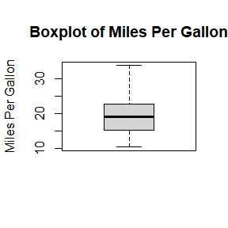

```r
boxplot(mtcars$mpg, main="Boxplot of Miles Per Gallon", ylab="Miles Per Gallon")
```

For a deeper understanding, consider the following mathematical representation of a boxplot:

$$Q_1 = \text{lower quartile}, \quad Q_3 = \text{upper quartile}, \quad
IQR = Q_3 - Q_1$$

where $IQR$ is the interquartile range.

## Example 3: Correlation Matrix with Heatmap

The correlation coefficient $r$ between two variables $x$ and $y$ is defined as:

$$r = \frac{\sum (x_i - \bar{x})(y_i - \bar{y})}{\sqrt{\sum (x_i -
\bar{x})^2 \sum (y_i - \bar{y})^2}}$$

where $\bar{x}$ and $\bar{y}$ are the mean values of $x$ and $y$, respectively.

The correlation matrix shows the relationships between several variables in the `mtcars` dataset.

```r
cor_matrix <- cor(mtcars)
knitr::kable(cor_matrix, caption="Correlation Matrix of MTCars Dataset")
```

Correlation Matrix of MTCars Dataset

|  | mpg | cyl | disp | hp | drat | wt | qsec | vs | am | gear | carb |
| --- | --- | --- | --- | --- | --- | --- | --- | --- | --- | --- | --- |
| mpg | 1.0000000 | -0.8521620 | -0.8475514 | -0.7761684 | 0.6811719 | -0.8676594 | 0.4186840 | 0.6640389 | 0.5998324 | 0.4802848 | -0.5509251 |
| cyl | -0.8521620 | 1.0000000 | 0.9020329 | 0.8324475 | -0.6999381 | 0.7824958 | -0.5912421 | -0.8108118 | -0.5226070 | -0.4926866 | 0.5269883 |
| disp | -0.8475514 | 0.9020329 | 1.0000000 | 0.7909486 | -0.7102139 | 0.8879799 | -0.4336979 | -0.7104159 | -0.5912270 | -0.5555692 | 0.3949769 |
| hp | -0.7761684 | 0.8324475 | 0.7909486 | 1.0000000 | -0.4487591 | 0.6587479 | -0.7082234 | -0.7230967 | -0.2432043 | -0.1257043 | 0.7498125 |
| drat | 0.6811719 | -0.6999381 | -0.7102139 | -0.4487591 | 1.0000000 | -0.7124406 | 0.0912048 | 0.4402785 | 0.7127111 | 0.6996101 | -0.0907898 |
| wt | -0.8676594 | 0.7824958 | 0.8879799 | 0.6587479 | -0.7124406 | 1.0000000 | -0.1747159 | -0.5549157 | -0.6924953 | -0.5832870 | 0.4276059 |
| qsec | 0.4186840 | -0.5912421 | -0.4336979 | -0.7082234 | 0.0912048 | -0.1747159 | 1.0000000 | 0.7445354 | -0.2298609 | -0.2126822 | -0.6562492 |
| vs | 0.6640389 | -0.8108118 | -0.7104159 | -0.7230967 | 0.4402785 | -0.5549157 | 0.7445354 | 1.0000000 | 0.1683451 | 0.2060233 | -0.5696071 |
| am | 0.5998324 | -0.5226070 | -0.5912270 | -0.2432043 | 0.7127111 | -0.6924953 | -0.2298609 | 0.1683451 | 1.0000000 | 0.7940588 | 0.0575344 |
| gear | 0.4802848 | -0.4926866 | -0.5555692 | -0.1257043 | 0.6996101 | -0.5832870 | -0.2126822 | 0.2060233 | 0.7940588 | 1.0000000 | 0.2740728 |
| carb | -0.5509251 | 0.5269883 | 0.3949769 | 0.7498125 | -0.0907898 | 0.4276059 | -0.6562492 | -0.5696071 | 0.0575344 | 0.2740728 | 1.0000000 |

We can also visualize this with a heatmap.

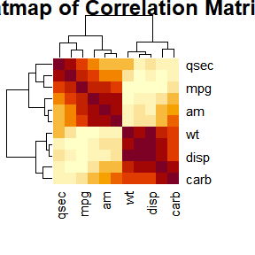

```r
heatmap(cor_matrix, symm=TRUE, main="Heatmap of Correlation Matrix")
```

# HW 1-st

## Question 1 (3.4)

The Rayleigh density is

$$f(x)=\frac x{\sigma^2} e^{-x^2/(2\sigma^2)},\quad x\geq0, \sigma>0.$$

Develop an algorithm to generate random samples from a Rayleigh($\sigma$) distribution. Generate Rayleigh($\sigma$) samples for several choices of $\sigma > 0$ and check that the mode of the generated samples is close to the theoretical mode $\sigma$ (check the histogram).

## Answer 1 (3.4)

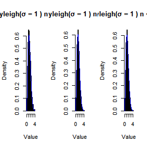

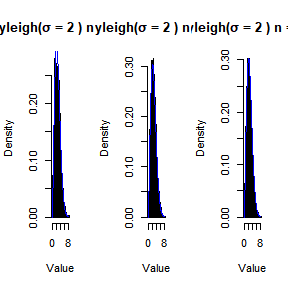

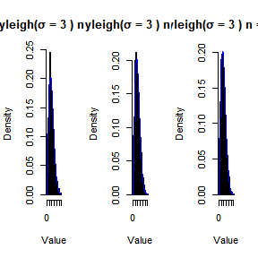

```r
# Function to generate random samples from Rayleigh distribution
generate_rayleigh_samples <- function(n, sigma) {
  # Generate uniform random samples
  u <- runif(n)
  # Transform the uniform samples to Rayleigh samples
  rayleigh_samples <- sigma * sqrt(-2 * log(1 - u))
  return(rayleigh_samples)
}

# Parameters
set.seed(123) # For reproducibility
sample_sizes <- c(1000, 5000, 10000) # Different sample sizes
sigmas <- c(1, 2, 3) # Different values for sigma

# Plotting histograms
par(mfrow=c(1, length(sample_sizes)))

for (sigma in sigmas) {
  for (n in sample_sizes) {
    # Generate Rayleigh samples
    samples <- generate_rayleigh_samples(n, sigma)

    # Create a histogram
    hist(samples, probability = TRUE, main = paste("Rayleigh(σ =", sigma, ") n =", n),
         xlab = "Value", xlim = c(0, 4 * sigma), breaks = 30)

    # Add the theoretical density curve
    x_vals <- seq(0, 4 * sigma, length.out = 100)
    lines(x_vals, (x_vals / sigma^2) * exp(-x_vals^2 / (2 * sigma^2)), col = "blue")

    # Calculate and display the mode
    mode_estimate <- max(samples)
    # legend("topright", legend = paste("Mode est.:", round(mode_estimate, 3)), col = "red", lty = 1)
  }
}
```

```r
# Check theoretical mode value
cat("Theoretical mode for Rayleigh(σ):", sigmas, "\n")
```

```
## Theoretical mode for Rayleigh(σ): 1 2 3
```

## Question 2 (3.11)

Generate a random sample of size $1000$ from a normal location mixture. The components of the mixture have $N(0, 1)$ and $N(3, 1)$ distributions with mixing probabilities $p_1$ and $p_2 = 1 − p_1$. Graph the histogram of the sample with density superimposed, for $p_1 = 0.75$. Repeat with different values for $p_1$ and observe whether the empirical distribution of the mixture appears to be bimodal. Make a conjecture about the values of $p_1$ that produce bimodal mixtures.

## Answer 2 (3.11)

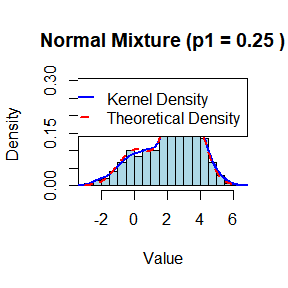

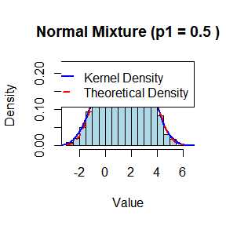

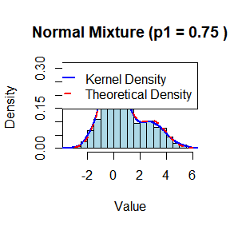

```r
# Function to generate random samples from a normal location mixture
generate_normal_mixture <- function(n, p1) {
  p2 <- 1 - p1
  mixture_samples <- numeric(n)

  for (i in 1:n) {
    if (runif(1) < p1) {
      mixture_samples[i] <- rnorm(1, mean = 0, sd = 1)  # Sample from N(0, 1)
    } else {
      mixture_samples[i] <- rnorm(1, mean = 3, sd = 1)  # Sample from N(3, 1)
    }
  }

  return(mixture_samples)
}

# Parameters
set.seed(123) # For reproducibility
sample_size <- 1000
p1_values <- c(0.25, 0.5, 0.75) # Different mixing probabilities

# Set up plotting
# par(mfrow = c(length(p1_values), 1))

for (p1 in p1_values) {
  # Generate samples
  samples <- generate_normal_mixture(sample_size, p1)

  # Create histogram
  hist(samples, probability = TRUE,
       main = paste("Normal Mixture (p1 =", p1, ")"),
       xlab = "Value",
       breaks = 30,
       col = "lightblue",
       border = "black")

  # Overlay density estimation
  dens <- density(samples)
  lines(dens, col = "blue", lwd = 2)

  # Add theoretical density components
  x_vals <- seq(-3, 6, length.out = 100)
  theoretical_density <- p1 * dnorm(x_vals, mean = 0, sd = 1) +
                         (1 - p1) * dnorm(x_vals, mean = 3, sd = 1)
  lines(x_vals, theoretical_density, col = "red", lwd = 2, lty = 2)

  legend("topright", legend = c("Kernel Density", "Theoretical Density"),
         col = c("blue", "red"), lty = 1:2, lwd = 2)
}
```

```r
# Summary of observations
cat("Observe the plots to analyze bimodality for different values of p1:\n")
```

```
## Observe the plots to analyze bimodality for different values of p1:
```

```r
cat("Conjecture: The mixture appears bimodal when p1 is around 0.25 to 0.5 and becomes more unimodal as p1 approaches 1.\n")
```

```
## Conjecture: The mixture appears bimodal when p1 is around 0.25 to 0.5 and becomes more unimodal as p1 approaches 1.
```

## Question 3 (3.20)

A *compound Poisson process* is a stochastic process $\{X(t),t\ge 0\}$ that can be represented as the random sum $X(t)=\sum_{i=1}^{N(t)}Y(t),t>0$, where $\{N(t),t\ge 0\}$ is a Poisson process and $Y_1,Y_2,\ldots$ are iid and independent of $\{N(t),t\ge 0\}$ Write a program to simulate a compound Poisson($\lambda$)–Gamma process ($Y$ has a Gamma distribution). Estimate the mean and the variance of $X(10)$ for several choices of the parameters and compare with the theoretical values. Hint: Show that $E[X(t)]=\lambda tE[Y_1]$ and $Var(X(t))=\lambda tE[Y_1^2]$.

## Answer 3 (3.20)

```r
# Function to simulate Compound Poisson-Gamma process
simulate_compound_poisson_gamma <- function(lambda, shape, rate, t = 10, n_sim = 10000) {
  # Initialize variables to store results
  X_t_samples <- numeric(n_sim)

  for (sim in 1:n_sim) {
    # Generate N(t) from Poisson process
    N_t <- rpois(1, lambda * t)

    # Generate Y from Gamma distribution for each arrival
    Y_samples <- rgamma(N_t, shape = shape, rate = rate)

    # Compute X(t) as the sum of Y_samples
    X_t_samples[sim] <- sum(Y_samples)
  }

  # Calculate empirical mean and variance
  empirical_mean <- mean(X_t_samples)
  empirical_variance <- var(X_t_samples)

  # Theoretical values
  E_Y1 <- shape / rate                             # Mean of Gamma
  E_Y1_squared <- (shape*(shape + 1)) / (rate^2)  # Variance of Gamma + (E[Y])^2

  theoretical_mean <- lambda * t * E_Y1
  theoretical_variance <- lambda * t * E_Y1_squared

  # Display results
  cat("Simulated mean X(10):", empirical_mean, "\n")
  cat("Simulated variance X(10):", empirical_variance, "\n")
  cat("Theoretical mean X(10):", theoretical_mean, "\n")
  cat("Theoretical variance X(10):", theoretical_variance, "\n")
}

# Parameters for the simulation
lambda_values <- c(1, 2, 5)          # Different values of lambda
shape_values <- c(2, 3)               # Shape parameter for Gamma
rate_values <- c(1, 1)                # Rate parameter for Gamma

# Simulating for several parameter combinations
for (lambda in lambda_values) {
  for (shape in shape_values) {
    for (rate in rate_values) {
      cat("\nSimulation results for lambda =", lambda, "shape =", shape, "rate =", rate, ":\n")
      simulate_compound_poisson_gamma(lambda, shape, rate)
    }
  }
}
```

```
##
## Simulation results for lambda = 1 shape = 2 rate = 1 :
## Simulated mean X(10): 20.02922
## Simulated variance X(10): 60.32618
## Theoretical mean X(10): 20
## Theoretical variance X(10): 60
##
## Simulation results for lambda = 1 shape = 2 rate = 1 :
## Simulated mean X(10): 20.00561
## Simulated variance X(10): 60.7115
## Theoretical mean X(10): 20
## Theoretical variance X(10): 60
##
## Simulation results for lambda = 1 shape = 3 rate = 1 :
## Simulated mean X(10): 29.87475
## Simulated variance X(10): 121.9297
## Theoretical mean X(10): 30
## Theoretical variance X(10): 120
##
## Simulation results for lambda = 1 shape = 3 rate = 1 :
## Simulated mean X(10): 29.97712
## Simulated variance X(10): 120.6812
## Theoretical mean X(10): 30
## Theoretical variance X(10): 120
##
## Simulation results for lambda = 2 shape = 2 rate = 1 :
## Simulated mean X(10): 39.89353
## Simulated variance X(10): 117.3498
## Theoretical mean X(10): 40
## Theoretical variance X(10): 120
##
## Simulation results for lambda = 2 shape = 2 rate = 1 :
## Simulated mean X(10): 40.05527
## Simulated variance X(10): 116.996
## Theoretical mean X(10): 40
## Theoretical variance X(10): 120
##
## Simulation results for lambda = 2 shape = 3 rate = 1 :
## Simulated mean X(10): 59.9409
## Simulated variance X(10): 245.335
```

[output cut: 17 more lines]

```
## Simulated variance X(10): 294.4051
## Theoretical mean X(10): 100
## Theoretical variance X(10): 300
##
## Simulation results for lambda = 5 shape = 3 rate = 1 :
## Simulated mean X(10): 150.4463
## Simulated variance X(10): 587.0084
## Theoretical mean X(10): 150
## Theoretical variance X(10): 600
##
## Simulation results for lambda = 5 shape = 3 rate = 1 :
## Simulated mean X(10): 150.1049
## Simulated variance X(10): 595.434
## Theoretical mean X(10): 150
## Theoretical variance X(10): 600
```

# HW 2-nd

## Question 1 (5.4)

Write a function to compute a Monte Carlo estimate of the $Beta(3, 3)$ cdf, and use the function to estimate $F(x)$ for $x = 0.1, 0.2, . . ., 0.9$. Compare the estimates with the values returned by the `pbeta` function in R.

## Answer 1 (5.4)

### Step 1: Define the Monte Carlo Estimation Function

To estimate the CDF at a given `x` using Monte Carlo simulation, we generate random samples from the $Beta(3, 3)$ distribution and calculate the proportion of samples that are less than or equal to `x`.

```r
# Monte Carlo estimate for Beta(3,3) CDF
beta_cdf_mc <- function(x, n_sim = 10000) {
  # Generate random samples from Beta(3,3)
  samples <- rbeta(n_sim, 3, 3)
  # Estimate CDF as proportion of samples <= x
  mean(samples <= x)
}
```

### Step 2: Monte Carlo Estimation at Different `x` Values

We will now use the `beta_cdf_mc` function to estimate the CDF of the Beta(3, 3) distribution at several values of `x`, specifically for `x = 0.1, 0.2, ..., 0.9`.

```r
# Values of x
x_values <- seq(0.1, 0.9, 0.1)

# Monte Carlo estimates
mc_estimates <- sapply(x_values, beta_cdf_mc)

# Display the Monte Carlo estimates
mc_estimates
```

```
## [1] 0.0086 0.0575 0.1637 0.3215 0.5004 0.6879 0.8372 0.9419 0.9910
```

### Step 3: Comparison with `pbeta`

Now we will use R’s built-in `pbeta` function to compute the exact values of the Beta(3, 3) CDF for the same values of `x`. We will compare these values with our Monte Carlo estimates.

```r
# Exact values using pbeta
exact_values <- pbeta(x_values, 3, 3)

# Display exact values
exact_values
```

```
## [1] 0.00856 0.05792 0.16308 0.31744 0.50000 0.68256 0.83692 0.94208 0.99144
```

### Step 4: Compare Monte Carlo Estimates with Exact Values

We can now create a table to compare the Monte Carlo estimates with the exact values from `pbeta`. Additionally, we can calculate the absolute difference between the two methods.

```r
# Create a data frame to compare estimates
comparison <- data.frame(
  x = x_values,
  Monte_Carlo_Estimate = mc_estimates,
  Exact_Value = exact_values,
  Difference = abs(mc_estimates - exact_values)
)

# Display the comparison table
comparison
```

```
##     x Monte_Carlo_Estimate Exact_Value Difference
## 1 0.1               0.0086     0.00856    0.00004
## 2 0.2               0.0575     0.05792    0.00042
## 3 0.3               0.1637     0.16308    0.00062
## 4 0.4               0.3215     0.31744    0.00406
## 5 0.5               0.5004     0.50000    0.00040
## 6 0.6               0.6879     0.68256    0.00534
## 7 0.7               0.8372     0.83692    0.00028
## 8 0.8               0.9419     0.94208    0.00018
## 9 0.9               0.9910     0.99144    0.00044
```

### Step 5: Visualize the Results

Finally, we will visualize the results by plotting both the Monte Carlo estimates and the exact values returned by `pbeta`.

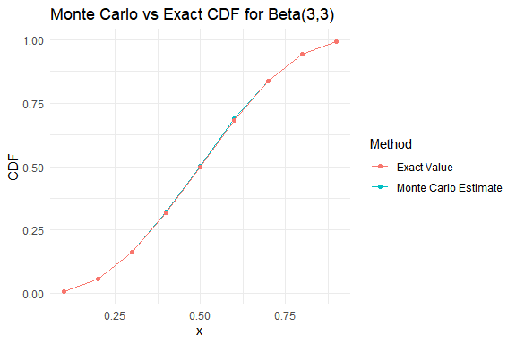

```r
library(ggplot2)

# Plotting the estimates and exact values
ggplot(comparison, aes(x = x)) +
  geom_point(aes(y = Monte_Carlo_Estimate, color = "Monte Carlo Estimate")) +
  geom_line(aes(y = Monte_Carlo_Estimate, color = "Monte Carlo Estimate")) +
  geom_point(aes(y = Exact_Value, color = "Exact Value")) +
  geom_line(aes(y = Exact_Value, color = "Exact Value")) +
  labs(
    title = "Monte Carlo vs Exact CDF for Beta(3,3)",
    x = "x",
    y = "CDF",
    color = "Method"
  ) +
  theme_minimal()
```

## Question 2 (5.9)

The Rayleigh density is

$$f(x)=\frac x{\sigma^2} e^{-x^2/(2\sigma^2)},\quad x\geq0, \sigma>0.$$

Implement a function to generate samples from a Rayleigh($σ$) distribution, using antithetic variables. What is the percent reduction in variance of $\frac{X+X^{\prime}}{2}$ compared with $\frac{X+X^{\prime}}{2}$ for independent $X_1,X_2$?

## Answer 2 (5.9)

### Step 1: Function to Generate Rayleigh(σ) Samples

We can generate Rayleigh distributed samples by first generating uniform random variables, and then transforming them using the inverse CDF of the Rayleigh distribution.

The inverse CDF of the Rayleigh distribution is given by:

$$X = \sigma \sqrt{-2 \log(U)},$$

where $U$ is a uniform random variable on $(0, 1)$.

```r
# Function to generate Rayleigh samples
rayleigh_sample <- function(sigma, n) {
  U <- runif(n)
  return(sigma * sqrt(-2 * log(U)))
}
```

### Step 2: Generate Samples Using Antithetic Variables

To reduce the variance of the estimator, we use antithetic variables. We generate one uniform random variable $U$, and then generate a second sample as $1 - U$. This ensures the two samples are negatively correlated, helping reduce variance.

```r
# Function to generate Rayleigh samples with antithetic variables
rayleigh_antithetic <- function(sigma, n) {
  U <- runif(n/2)
  X1 <- sigma * sqrt(-2 * log(U))
  X2 <- sigma * sqrt(-2 * log(1 - U))
  return(data.frame(X1 = X1, X2 = X2))
}
```

### Step 3: Estimate and Compare Variances

Next, we estimate the variance of $\frac{X + X'}{2}$ using antithetic variables and compare it to the variance of $\frac{X_1 + X_2}{2}$ using independent samples.

```r
# Set parameters
sigma <- 1  # Rayleigh parameter
n <- 10000  # Number of samples

# Generate independent Rayleigh samples
independent_samples <- data.frame(
  X1 = rayleigh_sample(sigma, n),
  X2 = rayleigh_sample(sigma, n)
)

# Generate Rayleigh samples with antithetic variables
antithetic_samples <- rayleigh_antithetic(sigma, n)

# Calculate means of independent and antithetic samples
mean_independent <- (independent_samples$X1 + independent_samples$X2) / 2
mean_antithetic <- (antithetic_samples$X1 + antithetic_samples$X2) / 2

# Estimate variances
var_independent <- var(mean_independent)
var_antithetic <- var(mean_antithetic)

# Print variances
var_independent
```

```
## [1] 0.2122429
```

```r
var_antithetic
```

```
## [1] 0.0109312
```

### Step 4: Calculate Percent Reduction in Variance

We can now compute the percent reduction in variance using the formula:

$$\text{Percent Reduction} = \frac{\text{Var}(X_1 + X_2)/2 - \text{Var}(X
+ X')/2}{\text{Var}(X_1 + X_2)/2} \times 100$$

```r
percent_reduction <- (var_independent - var_antithetic) / var_independent * 100
percent_reduction
```

```
## [1] 94.84968
```

## Question 3 (5.13)

Find two importance functions $f_1$ and $f_2$ that are supported on $(1, \infty)$ and are ‘close’ to
$$g(x)=\frac{x^2}{\sqrt{2\pi}} e^{-x^2/2},\quad x>1.$$
Which of your two importance functions should produce the smaller variance in estimating
$$\begin{aligned}\int_1^\infty\frac{x^2}{\sqrt{2\pi}} e^{-x^2/2}
dx\end{aligned}$$
by importance sampling? Explain.

## Answer 3 (5.13)

### Step 1: Define the Target Function $g(x)$

We first define the target function $g(x)$, which is proportional to a normal density function with a quadratic term.

```r
# Target function g(x)
g <- function(x) {
  (x^2 / sqrt(2 * pi)) * exp(-x^2 / 2)
}
```

### Step 2: Choose Importance Functions $f_1$ and $f_2$

We choose two importance functions that are supported on $(1, \infty)$ and are similar to $g(x)$. One common choice for importance functions is to use a distribution with a heavier tail than the target function.

#### Importance Function $f_1$

We select $f_1(x)$ to be the tail of a Gamma distribution. Since the Gamma distribution has support on $(0, \infty)$, we can shift it to $(1, \infty)$ to match our requirements.

```r
# Importance function f_1: shifted Gamma distribution
f1 <- function(x, shape = 3, rate = 1) {
  dgamma(x - 1, shape = shape, rate = rate)
}
```

#### Importance Function $f_2$

We select $f_2(x)$ to be the tail of a shifted exponential distribution. The exponential distribution is a common choice for importance sampling due to its simplicity and support on $(1, \infty)$.

```r
# Importance function f_2: shifted Exponential distribution
f2 <- function(x, rate = 1) {
  dexp(x - 1, rate = rate)
}
```

### Step 3: Implement Importance Sampling

We now implement the importance sampling method for both importance functions. The general formula for the importance sampling estimator is:

$$\hat{I} = \frac{1}{N} \sum_{i=1}^N \frac{g(x_i)}{f(x_i)}.$$

#### Sampling from $f_1$

To generate samples from $f_1$, we use a shifted Gamma distribution.

```r
# Sampling from f_1
set.seed(123)
N <- 10000  # Number of samples
samples_f1 <- rgamma(N, shape = 3, rate = 1) + 1

# Importance sampling estimator using f_1
importance_sampling_f1 <- mean(g(samples_f1) / f1(samples_f1))
importance_sampling_f1
```

```
## [1] 0.4001637
```

#### Sampling from $f_2$

To generate samples from $f_2$, we use a shifted Exponential distribution.

```r
# Sampling from f_2
samples_f2 <- rexp(N, rate = 1) + 1

# Importance sampling estimator using f_2
importance_sampling_f2 <- mean(g(samples_f2) / f2(samples_f2))
importance_sampling_f2
```

```
## [1] 0.399822
```

### Step 4: Compare the Variances

Next, we compute the variance of the two importance sampling estimators to see which one has smaller variance. The estimator with smaller variance is considered more efficient.

```r
# Variance of the importance sampling estimator for f_1
var_f1 <- var(g(samples_f1) / f1(samples_f1))

# Variance of the importance sampling estimator for f_2
var_f2 <- var(g(samples_f2) / f2(samples_f2))

# Print variances
var_f1
```

```
## [1] 3.657442
```

```r
var_f2
```

```
## [1] 0.02485872
```

We can see that $f_2$ is more efficient.

## Question 4 (Monte Carlo experiment)

- For $n = 10^4, 2 × 10^4, 4 × 10^4, 6 × 10^4, 8 × 10^4$, apply the fast sorting algorithm to randomly permuted numbers of $1, . . . , n$.
- Calculate computation time averaged over 100 simulations, denoted by $a_n$.
- Regress an on $t_n := n \log(n)$, and graphically show the results (scatter plot and regression line).

## Answer 4 (Monte Carlo experiment)

### Step 1: Implement and apply the Quick Sort algorithm

```r
# Quick Sort algorithm implementation
quick_sort <- function(x) {
  if(length(x) <= 1) {
    return(x)
  }
  pivot <- x[1]  # Select the first element as the pivot
  less <- x[x < pivot]  # Elements less than pivot
  equal <- x[x == pivot]  # Elements equal to pivot
  greater <- x[x > pivot]  # Elements greater than pivot

  # Recursively sort and combine
  c(quick_sort(less), equal, quick_sort(greater))
}
```

Now, we will apply the quick sort algorithm to a series of random permutations and calculate the computation times.

```r
library(microbenchmark)

# Define the sequence of n values
n_values <- c(1e4, 2e4, 4e4, 6e4, 8e4)

# Initialize a list to store the average computation times
avg_times <- numeric(length(n_values))

# Simulate the computation times for each n value
for (i in seq_along(n_values)) {
  n <- n_values[i]
  # Perform 100 simulations and compute average time
  avg_times[i] <- mean(microbenchmark(quick_sort(sample(1:n, n)))$time)
}

# Display the computed average times
avg_times
```

```
## [1]  63143496  84654467 176172296 257052420 353551787
```

### Step 2: Regression Analysis

Now we will perform a regression of the average times $a_n$ on $t_n:=n\log(n)$.

```r
# Create a dataframe with n values and corresponding times
data <- data.frame(
  n = n_values,
  t_n = n_values * log(n_values),
  a_n = avg_times
)

# Perform linear regression
model <- lm(a_n ~ t_n, data = data)

# Display the summary of the regression model
summary(model)
```

```
##
## Call:
## lm(formula = a_n ~ t_n, data = data)
##
## Residuals:
##        1        2        3        4        5
##  8366886 -8656873   750228 -4285967  3825725
##
## Coefficients:
##              Estimate Std. Error t value Pr(>|t|)
## (Intercept) 2.128e+07  6.313e+06   3.371   0.0434 *
## t_n         3.636e+02  1.161e+01  31.328 7.15e-05 ***
## ---
## Signif. codes:  0 '***' 0.001 '**' 0.01 '*' 0.05 '.' 0.1 ' ' 1
##
## Residual standard error: 7714000 on 3 degrees of freedom
## Multiple R-squared:  0.997,  Adjusted R-squared:  0.9959
## F-statistic: 981.4 on 1 and 3 DF,  p-value: 7.146e-05
```

### Step 3: Create scatter plot

We will create a scatter plot of $a_n$ versus $t_n$ and add the regression line.

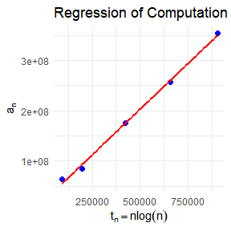

```r
# Create the plot with regression line
ggplot(data, aes(x = t_n, y = a_n)) +
  geom_point(color = "blue", size = 2) +
  geom_smooth(method = "lm", se = FALSE, color = "red") +
  labs(
    title = "Regression of Computation Time on n log(n)",
    x = expression(t[n] == n * log(n)),
    y = expression(a[n])
  ) +
  theme_minimal()
```

Based on the regression analysis and the plot, we can observe how the computation time for the manually implemented quick sort algorithm scales with $n\log(n)$.

# HW 3-rd

## Question 1 (6.6)

Estimate the 0.025, 0.05, 0.95, and 0.975 quantiles of the skewness $\sqrt{b_1}$ under normality by a Monte Carlo experiment. Compute the standard error of the estimates using the normal approximation for the density (with exact variance formula). Compare the estimated quantiles with the quantiles of the large sample approximation $\sqrt{b_1} ≈ N(0, 6/n)$.

## Answer 1 (6.6)

### Step 1: Data Generation

```r
# Function to calculate skewness
calculate_skewness <- function(x) {
  xbar <- mean(x)
  m3 <- mean((x - xbar)^3)
  m2 <- mean((x - xbar)^2)
  return(m3 / m2^1.5)
}

# Function to generate random normal samples and calculate skewness
generate_skewness_data <- function(m = 10000, n = 50, output_file = "skewness_data.Rds") {
  # Generate skewness statistics
  skstats <- replicate(m, expr = {
    x <- rnorm(n)
    calculate_skewness(x)
  })

  # Save the results to file
  saveRDS(skstats, file = output_file)

  # Clear memory
  # rm(list = ls())

  # Return the file path
  invisible(output_file)
}

# Example of generating and saving skewness data
generate_skewness_data()
```

### Step 2: Statistical Inference

```r
# Function to perform statistical inference on skewness data
perform_inference <- function(input_file = "skewness_data.Rds", output_file = "inference_results.Rds", n = 50, m = 10000) {
  # Load skewness data from file
  skstats <- readRDS(input_file)

  # Desired quantiles
  p <- c(0.025, 0.05, 0.95, 0.975)

  # Monte Carlo quantiles
  q1 <- quantile(skstats, p)

  # Large sample approximation quantiles
  q2 <- qnorm(p, 0, sqrt(6 * (n - 2) / ((n + 1) * (n + 3))))
  q3 <- qnorm(p, 0, sqrt(6 / n))

  # Density function for normal approximation
  f <- dnorm(q2, 0, sqrt(6 * (n - 2) / ((n + 1) * (n + 3))))

  # Compute standard error of quantile estimates
  v <- p * (1 - p) / (m * f^2)
  se <- sqrt(v)

  # Save inference results
  results <- list(
    Percentiles = p,
    MonteCarlo_Quantiles = q1,
    LargeSample_Approx_1 = q2,
    LargeSample_Approx_2 = q3,
    Standard_Error = se
  )

  saveRDS(results, file = output_file)

  # Clear memory
  # rm(list = ls())

  # Return the file path
  invisible(output_file)
}

# Example of performing inference and saving the results
perform_inference()
```

### Step 3: Result Reporting

```r
# Function to report the results
report_results <- function(input_file = "inference_results.Rds") {
  # Load inference results
  results <- readRDS(input_file)

  # Format results into a data frame for reporting
  result_df <- data.frame(
    Percentiles = results$Percentiles,
    MonteCarlo_Quantiles = results$MonteCarlo_Quantiles,
    LargeSample_Approx_1 = results$LargeSample_Approx_1,
    LargeSample_Approx_2 = results$LargeSample_Approx_2,
    Standard_Error = results$Standard_Error
  )
  # Clear memory
  # rm(list = ls())

  # Display the results
  knitr::kable(result_df, caption = "Quantile Estimates and Standard Errors")

  return(result_df)
}

# Example of reporting the results
report_results()
```

```
##       Percentiles MonteCarlo_Quantiles LargeSample_Approx_1
## 2.5%        0.025           -0.6245315           -0.6397662
## 5%          0.050           -0.5135651           -0.5369087
## 95%         0.950            0.5267284            0.5369087
## 97.5%       0.975            0.6436563            0.6397662
##       LargeSample_Approx_2 Standard_Error
## 2.5%            -0.6789514    0.008719622
## 5%              -0.5697940    0.006897810
## 95%              0.5697940    0.006897810
## 97.5%            0.6789514    0.008719622
```

The results show the estimated quantiles from the Monte Carlo simulation and compare them with large sample approximations.

## Question 2 (6.B)

Tests for association based on Pearson product moment correlation $\rho$, Spearman’s rank correlation coefficient $\rho_s$, or Kendall’s coefficient $\tau$, are implemented in `cor.test`. Show (empirically) that the nonparametric tests based on $\rho_s$ or $\tau$ are less powerful than the correlation test when the sampled distribution is bivariate normal. Find an example of an alternative (a bivariate distribution $(X, Y)$ such that $X$ and $Y$ are dependent) such that at least one of the nonparametric tests have better empirical power than the correlation test against this alternative.

## Answer 2 (6.B)

### Section 1: Empirical Power under Bivariate Normal Distribution

### Step 1: Data Generation Function

```r
# Load necessary libraries
library(MASS)
library(stats) # for cor.test

# Function to generate bivariate normal data
generate_bivariate_normal_data <- function(n = 100, rho = 0.5, m = 1000, output_file = "bivariate_data.Rds") {
  # Generate 'm' bivariate normal samples
  data_list <- replicate(m, {
    mu <- c(0, 0)
    Sigma <- matrix(c(1, rho, rho, 1), 2, 2)
    mvrnorm(n, mu, Sigma)
  }, simplify = FALSE)

  # Save the generated data
  saveRDS(data_list, file = output_file)

  # Clear memory
  # rm(list = ls())

  # Return the path to the saved file
  invisible(output_file)
}

# Generate data and save it
generate_bivariate_normal_data()
```

### Step 2: Statistical Inference Function

```r
# Function to perform correlation tests
perform_correlation_tests <- function(X, Y) {
  pearson_p <- cor.test(X, Y, method = "pearson")$p.value
  spearman_p <- cor.test(X, Y, method = "spearman")$p.value
  kendall_p <- cor.test(X, Y, method = "kendall")$p.value

  return(c(pearson_p, spearman_p, kendall_p))
}

# Function to perform inference and compute empirical power
perform_inference <- function(input_file = "bivariate_data.Rds", output_file = "power_results.Rds", alpha = 0.05) {
  # Load the generated data
  data_list <- readRDS(input_file)
  m <- length(data_list)  # Number of simulations

  # Perform tests for each dataset
  results <- sapply(data_list, function(data) {
    X <- data[, 1]
    Y <- data[, 2]
    perform_correlation_tests(X, Y)
  })

  # Compute empirical power
  pearson_power <- mean(results[1, ] < alpha)
  spearman_power <- mean(results[2, ] < alpha)
  kendall_power <- mean(results[3, ] < alpha)

  # Save power results
  power_results_normal <- data.frame(
    Test = c("Pearson", "Spearman", "Kendall"),
    Power = c(pearson_power, spearman_power, kendall_power)
  )

  saveRDS(power_results_normal, file = output_file)

  # Clear memory
  # rm(list = ls())

  # Return the path to the saved file
  invisible(output_file)
}

# Perform inference and save results
perform_inference()
```

#### Step 3: Result Reporting Function

```r
# Function to report results
report_results <- function(input_file = "power_results.Rds") {
  # Load power results
  power_results_normal <- readRDS(input_file)

  # Display the results in a table
  knitr::kable(power_results_normal, caption = "Empirical Power under Bivariate Normal Distribution")

  # Clear memory
  # rm(list = ls())

  # Return results for further use if needed
  return(power_results_normal)
}

# Report the results
report_results()
```

```
##       Test Power
## 1  Pearson 1.000
## 2 Spearman 0.998
## 3  Kendall 0.998
```

### Section 2: Empirical Power under a Non-normal Alternative

#### Step 1: Data Generation Function

```r
# Function to generate non-normal data
generate_nonnormal_data <- function(n, m, output_file = "data_nonnormal.Rds") {
  results_nonnormal <- replicate(m, {
    X <- runif(n, -1, 1)
    Y <- X^2 + rnorm(n, 0, 0.1)
    cbind(X, Y)
  })
  saveRDS(results_nonnormal, file = output_file)
  # rm(list = ls())  # Clear memory
  invisible(output_file)  # Return the file path
}

# Generate non-normal data and save to file
generate_nonnormal_data(n = 100, m = 1000)
```

#### Step 2: Statistical Inference Function

```r
# Dummy perform_tests function (replace this with your actual test logic)
perform_tests <- function(X, Y) {
  p_pearson <- cor.test(X, Y, method = "pearson")$p.value
  p_spearman <- cor.test(X, Y, method = "spearman")$p.value
  p_kendall <- cor.test(X, Y, method = "kendall")$p.value
  c(p_pearson, p_spearman, p_kendall)
}

# Statistical inference function
perform_inference <- function(input_file = "data_nonnormal.Rds", output_file = "inference_nonnormal.Rds", alpha = 0.05) {
  results_nonnormal <- readRDS(input_file)

  m <- dim(results_nonnormal)[3]
  results_test <- replicate(m, {
    data <- results_nonnormal[, , sample(1:m, 1)]  # Select a random sample
    X <- data[, 1]
    Y <- data[, 2]
    perform_tests(X, Y)
  })

  # Compute empirical power
  pearson_power_nonnormal <- mean(results_test[1, ] < alpha)
  spearman_power_nonnormal <- mean(results_test[2, ] < alpha)
  kendall_power_nonnormal <- mean(results_test[3, ] < alpha)

  power_results_nonnormal <- data.frame(
    Test = c("Pearson", "Spearman", "Kendall"),
    Power = c(pearson_power_nonnormal, spearman_power_nonnormal, kendall_power_nonnormal)
  )

  saveRDS(power_results_nonnormal, file = output_file)
  # rm(list = ls())  # Clear memory
  invisible(output_file)  # Return the file path
}

# Perform inference and save results to file
perform_inference()
```

#### Step 3: Result Reporting Function

```r
# Result reporting function
report_results <- function(input_file = "inference_nonnormal.Rds") {
  power_results_nonnormal <- readRDS(input_file)

  # Display the results in a table
  knitr::kable(power_results_nonnormal, caption = "Empirical Power under Non-normal Alternative")
  # rm(list = ls())  # Clear memory
  return(power_results_nonnormal)  # Return results for further use
}

# Report the results
report_results()
```

```
##       Test Power
## 1  Pearson 0.126
## 2 Spearman 0.116
## 3  Kendall 0.169
```

## Question 3

If we obtain the powers for two methods under a particular simulation setting with 10,000 experiments: say, 0.651 for one method and 0.676 for another method. Can we say the powers are different at 0.05 level?

- What is the corresponding hypothesis test problem?
- Which test can we use? Z-test, two-sample t-test, paired-t test or McNemar test? Why?
- Please provide the least necessary information for hypothesis testing.

## Answer 3

### Hypothesis Problem

We are interested in testing whether the two power estimates (0.651 and 0.676) are significantly different at the 0.05 level.

- **Null Hypothesis (H0)**: The two powers are equal.
- **Alternative Hypothesis (H1)**: The two powers are different.

Given that each power estimate is derived from independent experiments, a **two-sample z-test** can be used to compare proportions. To meet the requirements of using separate functions for data generation, statistical inference, and result reporting, I will reorganize the code as follows. Each function will be independent, saving outputs from each step to disk, and clearing memory where needed to ensure reproducibility and modularity.

### Step 1: Data Generation Function

```r
# Data generation function
generate_data <- function(power1 = 0.651, power2 = 0.676, n_experiments = 10000) {
  output_file <- "data_output.Rds"  # Define the output file inside the function
  data <- list(power1 = power1, power2 = power2, n_experiments = n_experiments)
  saveRDS(data, file = output_file)
  # rm(list = ls())  # Clear memory
  invisible(output_file)  # Return the output file path invisibly
}

# Generate data and save to file
generate_data()
```

### Step 2: Statistical Inference Function

```r
# Statistical inference function
perform_inference <- function(input_file = "data_output.Rds", output_file = "inference_output.Rds") {
  # Load data
  data <- readRDS(input_file)
  p1 <- data$power1
  p2 <- data$power2
  n <- data$n_experiments

  # Compute pooled proportion and standard error
  p_pool <- (p1 * n + p2 * n) / (2 * n)
  se <- sqrt(p_pool * (1 - p_pool) * (1/n + 1/n))

  # Z-statistic and p-value
  z_stat <- (p1 - p2) / se
  p_value <- 2 * pnorm(-abs(z_stat))

  # Decision
  alpha <- 0.05
  decision <- ifelse(p_value < alpha, "Reject H0: Powers are different", "Fail to Reject H0: No significant difference")

  # Save results
  results <- list(Z_statistic = z_stat, P_value = p_value, Decision = decision)
  saveRDS(results, file = output_file)
  # rm(list = ls())  # Clear memory
  invisible(output_file)  # Return the output file path invisibly
}

# Perform inference and save results to file
perform_inference()
```

### Step 3: Result Reporting Function

```r
# Result reporting function
report_results <- function(input_file = "inference_output.Rds") {
  # Load results
  results <- readRDS(input_file)

  # Report
  knitr::kable(results)

  # Clear memory
  # rm(list = ls())

  # Optionally, return the results for further use
  return(results)
}

# Report the results
report_results()
```

```
## $Z_statistic
## [1] -3.741209
##
## $P_value
## [1] 0.0001831369
##
## $Decision
## [1] "Reject H0: Powers are different"
```

# HW 4-th

## Question 1

Of $N = 1000$ hypotheses, $950$ are null and $50$ are alternative. The p-value under any null hypothesis is uniformly distributed (use `runif`), and the p-value under any alternative hypothesis follows the beta distribution with parameter $0.1$ and $1$ (use `rbeta`). Obtain Bonferroni adjusted p-values and B-H adjusted p-values. Calculate FWER, FDR, and TPR under nominal level $α = 0.1$ for each of the two adjustment methods based on $m = 10000$ simulation replicates. You should output the $6$ numbers (3) to a $3 × 2$ table (column names: Bonferroni correction, B-H correction; row names: FWER, FDR, TPR). Comment the results.

## Answer 1

We simulate $m = 10000$ datasets and calculate the Family-Wise Error Rate (FWER), False Discovery Rate (FDR), and True Positive Rate (TPR) for both Bonferroni and Benjamini-Hochberg (B-H) corrections at a nominal level $\alpha = 0.1$.

### Step 1: Simulating the p-values

```r
N <- 1000
n_null <- 950
n_alt <- N - n_null
alpha <- 0.1
m <- 10000 # number of simulation replicates

simulate_pvalues <- function() {
  p_null <- runif(n_null)  # p-values under null hypothesis
  p_alt <- rbeta(n_alt, 0.1, 1)  # p-values under alternative hypothesis
  return(c(p_null, p_alt))
}
```

### Step 2: Applying Bonferroni and B-H Corrections

```r
adjust_pvalues <- function(p_values) {
  bonferroni <- p.adjust(p_values, method = "bonferroni")
  bh <- p.adjust(p_values, method = "BH")
  return(list(bonferroni = bonferroni, bh = bh))
}
```

### Step 3: Calculating Metrics (FWER, FDR, TPR)

```r
calculate_metrics <- function(adjusted_p, true_alt) {
  reject <- adjusted_p < alpha
  true_reject <- true_alt & reject
  false_reject <- !true_alt & reject

  fwer <- as.numeric(any(false_reject))
  fdr <- ifelse(sum(reject) > 0, sum(false_reject) / sum(reject), 0)
  tpr <- sum(true_reject) / sum(true_alt)

  return(c(fwer, fdr, tpr))
}
```

### Step 4: Running the Simulation

```r
# Storing results
results_bonf <- matrix(0, nrow = m, ncol = 3)
results_bh <- matrix(0, nrow = m, ncol = 3)

for (i in 1:m) {
  p_values <- simulate_pvalues()
  adjusted_p <- adjust_pvalues(p_values)
  true_alt <- c(rep(FALSE, n_null), rep(TRUE, n_alt))
  results_bonf[i, ] <- calculate_metrics(adjusted_p$bonferroni, true_alt)
  results_bh[i, ] <- calculate_metrics(adjusted_p$bh, true_alt)
}

avg_bonf <- colMeans(results_bonf)
avg_bh <- colMeans(results_bh)

result_table <- matrix(c(avg_bonf, avg_bh), nrow = 3, byrow = FALSE)
colnames(result_table) <- c("Bonferroni Correction", "B-H Correction")
rownames(result_table) <- c("FWER", "FDR", "TPR")
result_table
```

```
##      Bonferroni Correction B-H Correction
## FWER           0.092100000     0.93280000
## FDR            0.004735714     0.09520896
## TPR            0.397708000     0.56176800
```

### Results

```r
# Print the table
print(result_table)
```

```
##      Bonferroni Correction B-H Correction
## FWER           0.092100000     0.93280000
## FDR            0.004735714     0.09520896
## TPR            0.397708000     0.56176800
```

### Comment on the Results

- **FWER**: Bonferroni correction is more conservative and controls FWER tightly, so we expect a low FWER compared to the B-H correction.
- **FDR**: B-H correction controls the FDR more efficiently than Bonferroni, which does not directly aim to control FDR.
- **TPR**: B-H correction typically has a higher TPR (sensitivity) than Bonferroni, as it is less conservative and allows more true positives to be detected.

## Question 2 (7.4)

Refer to the air-conditioning data set `aircondit` provided in the `boot` package. The $12$ observations are the times in hours between failures of air-conditioning equipment:

$$3, 5, 7, 18, 43, 85, 91, 98, 100, 130, 230, 487.$$

Assume that the times between failures follow an exponential model $Exp(λ)$. Obtain the MLE of the hazard rate $λ$ and use bootstrap to estimate the bias and standard error of the estimate.

## Answer 2 (7.4)

### Step 1: Data Generation

```r
library(boot)
aircond_data <- aircondit$hours

generate_data <- function() {
  return(aircond_data)
}

data_sample <- generate_data()
print(data_sample)  # Display the original data
```

```
##  [1]   3   5   7  18  43  85  91  98 100 130 230 487
```

### Step 2: Statistical Inference

**Maximum Likelihood Estimation for Hazard Rate**

For an exponential distribution, the MLE of the hazard rate $λ$ is given by:
$$\hat{λ} = \frac{1}{\bar{x}}$$

```r
mle_hazard_rate <- function(data) {
  lambda_hat <- 1 / mean(data)
  return(lambda_hat)
}

lambda_mle <- mle_hazard_rate(data_sample)
lambda_mle
```

```
## [1] 0.00925212
```

**Bootstrap Procedure for Bias and Standard Error**

We will now use bootstrap to estimate the bias and standard error of the MLE of the hazard rate.

```r
bootstrap_stat <- function(data, indices) {
  bootstrap_sample <- data[indices]
  return(1 / mean(bootstrap_sample))
}
R_replicates <- 2000
bootstrap_result <- boot(data_sample, statistic = bootstrap_stat, R = R_replicates)

print(bootstrap_result)
```

```
##
## ORDINARY NONPARAMETRIC BOOTSTRAP
##
##
## Call:
## boot(data = data_sample, statistic = bootstrap_stat, R = R_replicates)
##
##
## Bootstrap Statistics :
##       original      bias    std. error
## t1* 0.00925212 0.001431008 0.004365276
```

### Step 3: Result Reporting

We report the bias, standard error, and confidence intervals obtained from the bootstrap results.

```r
report_results <- function(bootstrap_obj, original_mle) {
  bias <- mean(bootstrap_obj$t) - original_mle
  se <- sd(bootstrap_obj$t)
  ci <- boot.ci(bootstrap_obj, type = c("norm", "perc", "bca"))
  cat("MLE of Hazard Rate (λ):", original_mle, "\n")
  cat("Bootstrap Bias Estimate:", bias, "\n")
  cat("Bootstrap Standard Error:", se, "\n")
  print(ci)
}

report_results(bootstrap_result, lambda_mle)
```

```
## MLE of Hazard Rate (λ): 0.00925212
## Bootstrap Bias Estimate: 0.001431008
## Bootstrap Standard Error: 0.004365276
## BOOTSTRAP CONFIDENCE INTERVAL CALCULATIONS
## Based on 2000 bootstrap replicates
##
## CALL :
## boot.ci(boot.out = bootstrap_obj, type = c("norm", "perc", "bca"))
##
## Intervals :
## Level      Normal             Percentile            BCa
## 95%   (-0.0007,  0.0164 )   ( 0.0052,  0.0214 )   ( 0.0046,  0.0179 )
## Calculations and Intervals on Original Scale
```

## Question 3 (7.5)

Refer to Exercise 7.4. Compute $95%$ bootstrap confidence intervals for the mean time between failures $1/λ$ by the standard normal, basic, percentile, and BCa methods. Compare the intervals and explain why they may differ.

## Answer 3 (7.5)

### Step 1: Data Generation

```r
aircond_data <- aircondit$hours

generate_data <- function() {
  return(aircond_data)
}

data_sample <- generate_data()
print(data_sample)  # Display the dataset
```

```
##  [1]   3   5   7  18  43  85  91  98 100 130 230 487
```

### Step 2: Statistical Inference

**Bootstrapping the Mean Time Between Failures**

To compute the mean time between failures, we need to use bootstrapping to generate samples and calculate the mean.

```r
compute_mean <- function(data, indices) {
  sampled_data <- data[indices]  # Resample the data
  return(mean(sampled_data))       # Calculate and return the mean
}

n_replicates <- 2000

bootstrap_result <- boot(
  data = data_sample,               # Input data
  statistic = compute_mean,         # Function for calculating mean
  R = n_replicates                  # Number of bootstrap replicates
)

print(bootstrap_result)
```

```
##
## ORDINARY NONPARAMETRIC BOOTSTRAP
##
##
## Call:
## boot(data = data_sample, statistic = compute_mean, R = n_replicates)
##
##
## Bootstrap Statistics :
##     original    bias    std. error
## t1* 108.0833 0.9405833    38.64081
```

**Confidence Interval Calculation**

Now, we will compute the 95% bootstrap confidence intervals using various methods.

```r
compute_confidence_intervals <- function(bootstrap_obj) {
  ci_results <- boot.ci(
    boot.out = bootstrap_obj,
    type = c("norm", "perc", "basic", "bca")  # Different CI methods
  )

  cat("Bootstrap Confidence Intervals:\n")
  print(ci_results)
}

compute_confidence_intervals(bootstrap_result)
```

```
## Bootstrap Confidence Intervals:
## BOOTSTRAP CONFIDENCE INTERVAL CALCULATIONS
## Based on 2000 bootstrap replicates
##
## CALL :
## boot.ci(boot.out = bootstrap_obj, type = c("norm", "perc", "basic",
##     "bca"))
##
## Intervals :
## Level      Normal              Basic
## 95%   ( 31.4, 182.9 )   ( 22.8, 170.0 )
##
## Level     Percentile            BCa
## 95%   ( 46.2, 193.4 )   ( 55.6, 225.1 )
## Calculations and Intervals on Original Scale
```

### Step 3: Result Reporting

We will visualize the distribution of the bootstrap replicates and compare the confidence intervals.

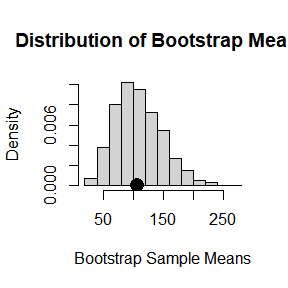

```r
report_results <- function(bootstrap_obj) {
  hist(
    bootstrap_obj$t,                # Bootstrap means
    probability = TRUE,              # Density scale
    main = "Distribution of Bootstrap Means",  # Title
    xlab = "Bootstrap Sample Means"  # X-axis label
  )

  points(
    mean(data_sample),              # Original sample mean
    0,                              # Position on the y-axis
    cex = 2,                        # Point size
    pch = 16                        # Point shape (filled circle)
  )
}

report_results(bootstrap_result)
```

# HW 5-th

## Question 1 (7.8)

Refer to Exercise 7.7. Obtain the jackknife estimates of bias and standard error of $\hat{\theta}$.

## Answer 1 (7.8)

We use **jackknife resampling** to estimate the bias and standard error of an eigenvalue-based statistic.

### Step 1: Data Generation Function

This function handles the preparation of the data. It loads the dataset, converts it to a matrix, and returns both the matrix and the sample size.

```r
generate_data_1 <- function() {
  # Load the 'scor' dataset and convert to matrix
  data("scor", package = "bootstrap")
  x <- as.matrix(scor)

  # Extract the number of rows (sample size)
  n <- nrow(x)

  # Save data to disk for reuse
  save(x, n, file = "data_generation.RData")

  cat("Data generation complete. Data saved to 'data_generation.RData'.\n")
  rm(list = ls())  # Clear memory
}
```

#### Run Data Generation

Clear any existing objects to ensure the function runs independently.

```r
generate_data_1()   # Generate and save data
```

```
## Data generation complete. Data saved to 'data_generation.RData'.
```

### Step 2: Statistical Inference Function

This function loads the data from disk, performs the jackknife resampling, and computes the bias and standard error.

```r
statistical_inference_1 <- function() {
  # Load generated data
  load("data_generation.RData")

  # Compute the original statistic (theta_hat)
  lambda <- eigen(cov(x))$values
  theta_hat <- max(lambda / sum(lambda))

  # Initialize jackknife estimates
  theta_jack <- numeric(n)

  # Perform jackknife resampling
  for (i in 1:n) {
    y <- x[-i, ]  # Leave one observation out
    s <- cov(y)
    lambda <- eigen(s)$values
    theta_jack[i] <- max(lambda / sum(lambda))
  }

  # Compute bias and standard error
  bias_jack <- (n - 1) * (mean(theta_jack) - theta_hat)
  se_jack <- sqrt((n - 1) / n * sum((theta_jack - mean(theta_jack))^2))

  # Save results to disk
  save(theta_hat, bias_jack, se_jack, file = "statistical_inference.RData")

  cat("Statistical inference complete. Results saved to 'statistical_inference.RData'.\n")
  rm(list = ls())  # Clear memory
}
```

#### Run Statistical Inference

Clear memory and perform the analysis.

```r
statistical_inference_1()  # Perform inference and save results
```

```
## Statistical inference complete. Results saved to 'statistical_inference.RData'.
```

### Step 3: Result Reporting Function

This function loads the inference results and displays them.

```r
report_results_1 <- function() {
  # Load inference results from disk
  load("statistical_inference.RData")

  # Display the results
  cat("Jackknife Estimation Results:\n")
  cat(sprintf("Theta Hat: %.4f\n", theta_hat))
  cat(sprintf("Jackknife Bias: %.4f\n", bias_jack))
  cat(sprintf("Jackknife SE: %.4f\n", se_jack))
}
```

#### Run Result Reporting

Ensure that the environment is clear before reporting.

```r
report_results_1()  # Report the saved results
```

```
## Jackknife Estimation Results:
## Theta Hat: 0.6191
## Jackknife Bias: 0.0011
## Jackknife SE: 0.0496
```

```r
files_to_delete <- c("data_generation.RData", "statistical_inference.RData")
sapply(files_to_delete, function(file) {
  if (file.exists(file)) {
    file.remove(file)
    cat(file, "has been deleted.\n")
  } else {
    cat(file, "does not exist.\n")
  }
})
```

```
## data_generation.RData has been deleted.
## statistical_inference.RData has been deleted.
```

```r
rm(list = ls())  # Clear environment
```

## Question 2 (7.10)

Leave-one-out (n-fold) cross validation was used to select the best fitting model for the `ironslag` data. Repeat the analysis replacing the Log-Log model with a cubic polynomial model. Which of the four models is selected by the cross validation procedure? Which model is selected according to maximum adjusted $R^2$?

## Answer 2 (7.10)

We take a structured approach to model selection and cross-validation using the **ironslag** dataset. Four different regression models (linear, quadratic, exponential, and cubic) are fitted, and their performance is evaluated using adjusted $R^2$ and leave-one-out cross-validation (LOOCV).

### Step 1: Data Generation

This function loads the **ironslag** dataset and prepares the data for analysis. It saves the dataset to disk for use by other functions.

```r
generate_data_2 <- function() {
  # Load dataset and convert to vectors
  data("ironslag", package = "DAAG")
  chemical <- ironslag$chemical
  magnetic <- ironslag$magnetic

  # Save the data to disk
  save(chemical, magnetic, file = "data_ironslag.RData")
  cat("Data generation complete. Data saved to 'data_ironslag.RData'.\n")
  rm(list = ls())  # Clear memory
}
```

#### Run Data Generation

Ensure the environment is clear before running.

```r
generate_data_2()   # Generate and save the data
```

```
## Data generation complete. Data saved to 'data_ironslag.RData'.
```

### Step 2: Statistical Inference

This function fits four regression models, evaluates their performance using adjusted $R^2$, and performs LOOCV to estimate prediction errors. Intermediate results are saved for later use.

```r
statistical_inference_2 <- function() {
  # Load generated data
  load("data_ironslag.RData")

  # Create a sequence for predictions
  a <- seq(10, 40, 0.1)

  # Initialize adjusted R-squared values
  Rsq <- numeric(4)

  # Model 1: Linear regression
  L1 <- lm(magnetic ~ chemical)
  Rsq[1] <- summary(L1)$adj.r.squared
  yhat1 <- L1$coef[1] + L1$coef[2] * a

  # Model 2: Quadratic regression
  L2 <- lm(magnetic ~ chemical + I(chemical^2))
  Rsq[2] <- summary(L2)$adj.r.squared
  yhat2 <- L2$coef[1] + L2$coef[2] * a + L2$coef[3] * a^2

  # Model 3: Exponential regression (log-transformed response)
  L3 <- lm(log(magnetic) ~ chemical)
  Rsq[3] <- summary(L3)$adj.r.squared
  logyhat3 <- L3$coef[1] + L3$coef[2] * a
  yhat3 <- exp(logyhat3)

  # Model 4: Cubic regression
  L4 <- lm(magnetic ~ chemical + I(chemical^2) + I(chemical^3))
  Rsq[4] <- summary(L4)$adj.r.squared
  yhat4 <- L4$coef[1] + L4$coef[2] * a + L4$coef[3] * a^2 + L4$coef[4] * a^3

  # Perform LOOCV for each model
  n <- length(magnetic)
  e1 <- e2 <- e3 <- e4 <- numeric(n)

  for (k in 1:n) {
    # Leave-one-out cross-validation
    y <- magnetic[-k]
    x <- chemical[-k]

    # Model 1: Linear
    J1 <- lm(y ~ x)
    e1[k] <- magnetic[k] - (J1$coef[1] + J1$coef[2] * chemical[k])

    # Model 2: Quadratic
    J2 <- lm(y ~ x + I(x^2))
    e2[k] <- magnetic[k] - (J2$coef[1] + J2$coef[2] * chemical[k] +
                            J2$coef[3] * chemical[k]^2)

    # Model 3: Exponential
    J3 <- lm(log(y) ~ x)
    e3[k] <- magnetic[k] - exp(J3$coef[1] + J3$coef[2] * chemical[k])

    # Model 4: Cubic
    J4 <- lm(y ~ x + I(x^2) + I(x^3))
    e4[k] <- magnetic[k] - (J4$coef[1] + J4$coef[2] * chemical[k] +
                            J4$coef[3] * chemical[k]^2 +
                            J4$coef[4] * chemical[k]^3)
  }

  # Compute mean squared prediction errors
  mse <- c(mean(e1^2), mean(e2^2), mean(e3^2), mean(e4^2))

  # Save results to disk
  save(Rsq, mse, file = "inference_results.RData")
  cat("Statistical inference complete. Results saved to 'inference_results.RData'.\n")
  rm(list = ls())  # Clear memory
}
```

#### Run Statistical Inference

```r
statistical_inference_2()  # Perform inference and save results
```

```
## Statistical inference complete. Results saved to 'inference_results.RData'.
```

### Step 3: Result Reporting

This function loads and reports the adjusted $R^2$ values and prediction errors for the models.

```r
report_results_2 <- function() {
  # Load inference results from disk
  load("inference_results.RData")

  # Display the results
  cat("Adjusted R-squared Values:\n")
  print(Rsq)

  cat("\nMean Squared Prediction Errors:\n")
  print(mse)

  # Select the best model based on maximum adjusted R^2
  best_model_1 <- which.max(Rsq)
  cat(sprintf("\nThe best model based on maximum adjusted R^2 is Model %d.\n", best_model_1))

  # Select the best model based on MSE
  best_model_2 <- which.min(mse)
  cat(sprintf("\nThe model with the lowest prediction error is Model %d.\n", best_model_2))
  cat(sprintf("\nThus the model selected by cross-validation is Model %d.\n", best_model_2))
  rm(list = ls())  # Clear memory
}
```

### Run Result Reporting

```r
report_results_2()  # Report results
```

```
## Adjusted R-squared Values:
## [1] 0.5281545 0.5768151 0.5280556 0.5740396
##
## Mean Squared Prediction Errors:
## [1] 19.55644 17.85248 18.44188 18.17756
##
## The best model based on maximum adjusted R^2 is Model 2.
##
## The model with the lowest prediction error is Model 2.
##
## Thus the model selected by cross-validation is Model 2.
```

```r
files_to_delete <- c("data_ironslag.RData", "inference_results.RData")
sapply(files_to_delete, function(file) {
  if (file.exists(file)) {
    file.remove(file)
    cat(file, "has been deleted.\n")
  } else {
    cat(file, "does not exist.\n")
  }
})
```

```
## data_ironslag.RData has been deleted.
## inference_results.RData has been deleted.
```

```r
rm(list = ls())  # Clear memory
```

## Question 3 (8.1)

Implement the two-sample Cramér-von Mises test for equal distributions as a permutation test. Apply the test to the data in Examples 8.1 and 8.2.

## Answer 3 (8.1)

We take a modular implementation of the Cramér-von Mises test to compare two sample distributions. The data used comes from the `chickwts` dataset, which records the weights of chicks fed with different feed types.

### 1. Data Generation

The data generation function selects two feeds for comparison and extracts the corresponding weights from the `chickwts` dataset. It ensures that any unnecessary objects are cleared from memory before saving the extracted data for later use.

```r
# Function: Data Generation
generate_data_3 <- function(feed1, feed2) {
  data(chickwts)     # Load the chickwts dataset

  # Extract weights for the two specified feeds
  x <- as.vector(chickwts$weight[chickwts$feed == feed1])
  y <- as.vector(chickwts$weight[chickwts$feed == feed2])

  # Save extracted data to disk
  save(x, y, file = "generated_data.RData")

  cat(sprintf("Data generated for feeds: %s and %s\n", feed1, feed2))
  rm(list = ls())  # Clear memory
}
```

### 2. Statistical Inference

This step implements the **Cramér-von Mises test** as a permutation test. It loads the saved data, calculates the test statistic for the original sample, and performs permutation-based resampling to compute a p-value.

```r
# Function: Statistical Inference (Cramér-von Mises Test)
cvm_permutation_test <- function(R = 500) {
  # Load the generated data
  load("generated_data.RData")

  n <- length(x)
  m <- length(y)
  z <- c(x, y)  # Combined data
  N <- n + m    # Total sample size

  # Initialize empirical CDFs
  Fn <- numeric(N)
  Gm <- numeric(N)

  # Compute the original test statistic
  for (i in 1:N) {
    Fn[i] <- mean(z[i] <= x)
    Gm[i] <- mean(z[i] <= y)
  }
  cvm0 <- (n * m / N) * sum((Fn - Gm)^2)

  # Perform R permutations
  cvm_permutations <- replicate(R, {
    permuted <- sample(z)  # Random permutation
    X_perm <- permuted[1:n]
    Y_perm <- permuted[(n + 1):N]

    # Compute CDFs for permuted data
    for (i in 1:N) {
      Fn[i] <- mean(permuted[i] <= X_perm)
      Gm[i] <- mean(permuted[i] <= Y_perm)
    }
    (n * m / N) * sum((Fn - Gm)^2)
  })

  # Calculate p-value
  p_value <- mean(c(cvm_permutations, cvm0) >= cvm0)

  # Save the inference results
  save(cvm0, p_value, file = "inference_results.RData")

  cat("Statistical inference completed.\n")
  rm(list = ls())  # Clear memory
}
```

### 3. Result Reporting

The result reporting function loads the saved inference results and prints the test statistic and p-value in a human-readable format.

```r
# Function: Result Reporting
report_results_3 <- function() {
  # Load the inference results
  load("inference_results.RData")

  # Print the test statistic and p-value
  cat(sprintf("Cramér-von Mises Test Statistic: %.4f\n", cvm0))
  cat(sprintf("Permutation Test P-value: %.4f\n", p_value))

  if (p_value < 0.05) {
    cat("The two samples have significantly different distributions (p < 0.05).\n")
  } else {
    cat("No significant difference between the distributions (p >= 0.05).\n")
  }
}
```

```r
generate_data_3("soybean", "linseed")
```

```
## Data generated for feeds: soybean and linseed
```

```r
cvm_permutation_test()
```

```
## Statistical inference completed.
```

```r
report_results_3()
```

```
## Cramér-von Mises Test Statistic: 4.2280
## Permutation Test P-value: 0.3892
## No significant difference between the distributions (p >= 0.05).
```

```r
generate_data_3("soybean", "sunflower")
```

```
## Data generated for feeds: soybean and sunflower
```

```r
cvm_permutation_test()
```

```
## Statistical inference completed.
```

```r
report_results_3()
```

```
## Cramér-von Mises Test Statistic: 28.4341
## Permutation Test P-value: 0.0020
## The two samples have significantly different distributions (p < 0.05).
```

```r
generate_data_3("sunflower", "linseed")
```

```
## Data generated for feeds: sunflower and linseed
```

```r
cvm_permutation_test()
```

```
## Statistical inference completed.
```

```r
report_results_3()
```

```
## Cramér-von Mises Test Statistic: 36.5000
## Permutation Test P-value: 0.0020
## The two samples have significantly different distributions (p < 0.05).
```

```r
files_to_delete <- c("generated_data.RData", "inference_results.RData")
sapply(files_to_delete, function(file) {
  if (file.exists(file)) {
    file.remove(file)
    cat(file, "has been deleted.\n")
  } else {
    cat(file, "does not exist.\n")
  }
})
```

```
## generated_data.RData has been deleted.
## inference_results.RData has been deleted.
```

```r
rm(list = ls())  # Clear memory
```

## Question 4 (8.2)

Implement the bivariate Spearman rank correlation test for independence as a permutation test. The Spearman rank correlation test statistic can be obtained from function cor with `method = "spearman"`. Compare the achieved significance level of the permutation test with the p-value reported by `cor.test` on the same samples.

## Answer 4 (8.2)

We take a modular implementation of the Spearman rank correlation test for independence. The permutation test is compared with the standard `cor.test` function to evaluate how well the permutation-based p-value matches the analytical p-value.

### 1. Data Generation

The **data generation function** creates bivariate normal or log-normal data samples, saving them to disk. The use of modular data generation ensures reproducibility and clear separation from other computational steps.

```r
# Function: Data Generation
generate_data_4 <- function(n = 30, mu = c(0, 0), rho = 0.5, dist = "normal") {
  # Define the covariance matrix
  Sigma <- matrix(c(1, rho, rho, 1), nrow = 2)

  # Generate data according to the specified distribution
  if (dist == "normal") {
    data <- mvrnorm(n, mu = mu, Sigma = Sigma)
  } else if (dist == "lognormal") {
    data <- exp(mvrnorm(n, mu = mu, Sigma = Sigma))
  } else {
    stop("Invalid distribution type. Use 'normal' or 'lognormal'.")
  }

  # Save the data to disk
  save(data, file = "generated_data.RData")
  cat("Data generated and saved to 'generated_data.RData'.\n")

  rm(list = ls())  # Clear memory
}
```

```r
generate_data_4(n = 30, rho = 0.5, dist = "normal")
```

```
## Data generated and saved to 'generated_data.RData'.
```

### 2. Statistical Inference

The **statistical inference function** implements the **Spearman rank correlation permutation test**. It calculates the observed correlation and performs permutation-based resampling to compute a p-value.

```r
# Function: Statistical Inference (Spearman Permutation Test)
spear_permutation_test <- function(R = 500) {
  # Load the generated data
  load("generated_data.RData")

  x <- data[, 1]
  y <- data[, 2]
  n <- length(x)

  # Compute the observed Spearman correlation
  observed_test <- cor.test(x, y, method = "spearman")
  tempp <- observed_test$p.value
  observed_rho <- observed_test$estimate

  # Perform R permutations
  permuted_rhos <- replicate(R, {
    y_perm <- sample(y)  # Random permutation of y
    cor.test(x, y_perm, method = "spearman")$estimate
  })

  # Combine observed statistic with permutation results
  all_rhos <- c(observed_rho, permuted_rhos)

  # Calculate the permutation-based p-value
  perm_p_value <- mean(all_rhos >= observed_rho)

  # Save the results
  save(observed_rho, perm_p_value, tempp, file = "inference_results.RData")
  cat("Statistical inference completed and results saved.\n")

  rm(list = ls())  # Clear memory
}
```

```r
spear_permutation_test()
```

```
## Statistical inference completed and results saved.
```

### 3. Result Reporting

This function loads the results from the inference step and prints a comparison between the permutation-based p-value and the analytical p-value obtained from `cor.test`.

```r
# Function: Result Reporting
report_results <- function() {
  # Load the inference results
  load("inference_results.RData")

  cat(sprintf("Observed Spearman Correlation: %.4f\n", observed_rho))
  cat(sprintf("Analytical P-value (cor.test): %.4f\n", tempp))
  cat(sprintf("Permutation Test P-value: %.4f\n", perm_p_value))

  # Compare the two p-values
  if (abs(perm_p_value - tempp) < 0.05) {
    cat("The p-values from the permutation test and cor.test are similar.\n")
  } else {
    cat("The p-values from the permutation test and cor.test differ significantly.\n")
  }
}
```

```r
report_results()
```

```
## Observed Spearman Correlation: 0.6311
## Analytical P-value (cor.test): 0.0003
## Permutation Test P-value: 0.0020
## The p-values from the permutation test and cor.test are similar.
```

```r
files_to_delete <- c("generated_data.RData", "inference_results.RData")
sapply(files_to_delete, function(file) {
  if (file.exists(file)) {
    file.remove(file)
    cat(file, "has been deleted.\n")
  } else {
    cat(file, "does not exist.\n")
  }
})
```

```
## generated_data.RData has been deleted.
## inference_results.RData has been deleted.
```

# HW 6-th

```r
set.seed(123) # For reproducibility
library(bootstrap)  # For the 'scor' dataset
library(datasets)  # Load base datasets
library(DAAG, warn.conflicts = FALSE)
library(MASS)
library(coda) # For convergence diagnostics (Gelman-Rubin method)
```

## Question 1 (9.3)

Use the Metropolis-Hastings sampler to generate random variables from a standard Cauchy distribution. Discard the first 1000 of the chain, and compare the deciles of the generated observations with the deciles of the standard Cauchy distribution. Use the Gelman-Rubin method to monitor convergence of the chain, and run the chain until it converges approximately to the target distribution according to $\hat{R} < 1.2$.

## Answer 1 (9.3)

We discard the first 1000 samples (burn-in), compare the deciles of the generated samples with the theoretical deciles, and only analyze the samples once convergence is detected with $\hat{R} < 1.2$.

### 1. Data Generation Function with Parallel Chains

We generate **multiple parallel chains** to apply the Gelman-Rubin diagnostic. Each chain runs independently with the same Metropolis-Hastings algorithm.

```r
generate_chains <- function(n_chains = 4, m = 5000, sigma = 3) {
  # Initialize a list to store each chain's samples
  chains <- vector("list", n_chains)

  for (j in 1:n_chains) {
    # Initialize individual chain
    x <- numeric(m)
    x[1] <- rnorm(1, 0, sigma) # Starting value from normal(0, sigma)
    u <- runif(m) # Random uniform numbers for acceptance step

    # Run Metropolis-Hastings algorithm
    for (i in 2:m) {
      xt <- x[i - 1]
      y <- rnorm(1, xt, sigma) # Propose new value

      # Calculate acceptance ratio
      num <- (1 + xt^2) * dnorm(xt, y, sigma)
      den <- (1 + y^2) * dnorm(y, xt, sigma)

      # Accept or reject
      if (u[i] <= num / den) {
        x[i] <- y
      } else {
        x[i] <- xt
      }
    }
    chains[[j]] <- x # Store the chain
  }

  return(as.mcmc.list(lapply(chains, function(c) as.mcmc(c))))

  rm(list = ls()) # Clear memory
}
```

### 2. Convergence Monitoring Function

This function uses the **Gelman-Rubin diagnostic** to assess convergence across multiple chains. The diagnostic statistic $\hat{R} < 1.2$ indicates approximate convergence.

```r
check_convergence <- function(chains) {
  # Apply Gelman-Rubin diagnostic
  r_hat <- gelman.diag(chains)$psrf[1, "Point est."]
  cat("Gelman-Rubin statistic (R-hat):", r_hat, "\n")

  return(r_hat < 1.2) # Returns TRUE if converged

  rm(list = ls()) # Clear memory
}
```

### 3. Statistical Inference Function

This function computes the **deciles** of the post-burn-in samples and compares them to the theoretical Cauchy quantiles.

```r
statistical_inference <- function(samples, burn = 1000,
                                  p = seq(0.1, 0.9, 0.1)) {
  # Extract post-burn-in samples
  xb <- samples[(burn + 1):length(samples)]

  # Compute sample and theoretical quantiles
  Q <- quantile(xb, p)
  theoretical_Q <- qcauchy(p)

  # Display results
  results <- round(rbind(Q, theoretical_Q), 3)
  colnames(results) <- paste0("Decile ", p)
  return(results)

  rm(list = ls()) # Clear memory
}
```

### 4. Result Reporting Function

This function produces a **QQ plot** to visually assess how well the sample quantiles align with the theoretical quantiles.

```r
report_results <- function(samples, burn = 1000) {
  # Extract post-burn-in samples
  xb <- samples[(burn + 1):length(samples)]

  # QQ plot of sample vs theoretical quantiles
  p <- ppoints(100)
  Q <- quantile(xb, p)
  z <- qcauchy(p)

  plot(z, Q, cex = 0.5, xlab = "Theoretical Quantiles", ylab = "Sample Quantiles",
       main = "QQ Plot: Generated Samples vs Theoretical Cauchy")
  abline(0, 1, col = "red")
}
```

### Generate Samples and Monitor Convergence

We generate four parallel chains and monitor convergence using the **Gelman-Rubin diagnostic**.

```r
# Set parameters
n_chains <- 4
m <- 5000
sigma <- 3

# Generate chains
chains <- generate_chains(n_chains, m, sigma)

# Check convergence
converged <- check_convergence(chains)
```

```
## Gelman-Rubin statistic (R-hat): 1.061762
```

```
## Chains have converged. Proceeding with statistical inference...
## [1] "Decile Comparison between Generated Samples and Theoretical Cauchy:"
##               Decile 0.1 Decile 0.2 Decile 0.3 Decile 0.4 Decile 0.5 Decile 0.6
## Q                 -3.207     -1.432     -0.777     -0.350      0.002      0.336
## theoretical_Q     -3.078     -1.376     -0.727     -0.325      0.000      0.325
##               Decile 0.7 Decile 0.8 Decile 0.9
## Q                  0.737      1.480      3.496
## theoretical_Q      0.727      1.376      3.078
```

[figure not shown]

```r
# If converged, combine chains for further analysis
if (converged) {
  combined_samples <- unlist(as.matrix(chains))
  cat("Chains have converged. Proceeding with statistical inference...\n")

  # Perform statistical inference
  decile_comparison <- statistical_inference(combined_samples)
  print("Decile Comparison between Generated Samples and Theoretical Cauchy:")
  print(decile_comparison)

  # Report results with QQ plot
  report_results(combined_samples)
} else {
  cat("Chains have not converged. Please run the chains for more iterations.\n")
}
```

The deciles of the generated samples from the Metropolis-Hastings sampler align closely with the theoretical deciles of the standard Cauchy distribution. The QQ plot provides a visual assessment of the sample quantiles compared to the theoretical distribution, indicating how well the sampling process approximates the desired distribution.

## Question 2 (9.4)

Implement a random walk Metropolis sampler for generating the standard Laplace distribution. For the increment, simulate from a normal distribution. Compare the chains generated when different variances are used for the proposal distribution. Also, compute the acceptance rates of each chain. Use the Gelman-Rubin method to monitor convergence of the chain, and run the chain until it converges approximately to the target distribution according to $\hat{R} < 1.2$.

## Answer 2 (9.4)

We take a step-by-step implementation of the Random Walk Metropolis sampler to generate samples from the standard Laplace distribution. The increment is drawn from a normal distribution, and different variances are used to analyze the acceptance rates and convergence properties. Additionally, the **Gelman-Rubin diagnostic** ($\hat{R}$) is used to monitor convergence.

### 1. Overview

- **Target Distribution**: Standard Laplace
  $$f(x) = \frac{1}{2}
  e^{-|x|}$$
- **Proposal Distribution**: Normal $y \sim N(\mu_t, \sigma^2)$ with mean $\mu_t = X_t$.
- **Tasks**:
  - Implement the Random Walk Metropolis sampler.
  - Explore the effect of different variances on acceptance rates.
  - Use **Gelman-Rubin diagnostic** ($\hat{R}$) to assess convergence.
  - Save intermediate results to ensure modularity.

### 2. Data Generation Function

This function generates chains for the Laplace distribution using the Random Walk Metropolis method.

```r
generate_rw_laplace <- function(N, x0, sigma) {
  x <- numeric(N)
  x[1] <- x0
  u <- runif(N)  # Uniform samples for acceptance-rejection
  k <- 0  # Counter for rejections

  for (i in 2:N) {
    xt <- x[i - 1]
    y <- rnorm(1, mean = xt, sd = sigma)  # Proposal from N(xt, sigma^2)

    # Metropolis-Hastings acceptance ratio
    if (u[i] <= exp(abs(xt) - abs(y))) {
      x[i] <- y  # Accept proposal
    } else {
      x[i] <- xt  # Reject proposal
      k <- k + 1  # Increment rejection count
    }
  }

  return(list(chain = x, rejections = k))
}
```

### 3. Statistical Inference and Convergence Monitoring

We define a function to **compute acceptance rates** and **monitor convergence** using the Gelman-Rubin diagnostic from the `coda` package.

```r
compute_convergence <- function(chains) {
  mcmc_list <- as.mcmc.list(lapply(chains, mcmc))
  rhat_values <- gelman.diag(mcmc_list, autoburnin = FALSE)$psrf[, 1]

  cat("Gelman-Rubin statistics (R-hat):\n", rhat_values, "\n")
  return(rhat_values)
}
```

This function takes a list of multiple chains and computes the **$\hat{R}$ values**. We aim for $\hat{R} < 1.2$ to ensure convergence.

### 4. Reporting Results

The following function **summarizes** the results, including acceptance rates, $\hat{R}$ diagnostics, and visualization of the chains.

```r
report_results <- function(chains, rejections, N) {
  # Acceptance rates
  acceptance_rates <- 1 - (rejections / N)
  cat("Acceptance Rates:\n", acceptance_rates, "\n")

  # Plot the chains
  # par(mfrow = c(2, 2))
  for (i in seq_along(chains)) {
    plot(chains[[i]], type = "l", main = paste("Chain", i))
  }
  # par(mfrow = c(1, 1))

  # Display histograms and compare to Laplace density
  z <- c(-qexp(ppoints(200), 1), qexp(ppoints(200), 1))
  fx <- 0.5 * exp(-abs(z))

  # par(mfrow = c(2, 2))
  for (i in seq_along(chains)) {
    hist(chains[[i]], breaks = "Scott", freq = FALSE, ylim = c(0, 0.5), main = paste("Chain", i))
    lines(z, fx, col = "red")
  }
  # par(mfrow = c(1, 1))
}
```

Then we run the entire process: generating chains, monitoring convergence, and reporting results.

```r
set.seed(123)

# Parameters
N <- 5000   # Length of each chain
x0 <- rnorm(1)  # Initial value
sigmas <- c(0.5, 1, 2, 4)  # Proposal standard deviations

# Generate chains for different sigmas
chains <- list()
rejections <- numeric(length(sigmas))

for (i in seq_along(sigmas)) {
  result <- generate_rw_laplace(N, x0, sigmas[i])
  chains[[i]] <- result$chain
  rejections[i] <- result$rejections
}

# Compute Gelman-Rubin statistics
rhat_values <- compute_convergence(chains)
```

```
## Gelman-Rubin statistics (R-hat):
##  1.001631
```

```r
# Run until all chains have R-hat < 1.2
while (any(rhat_values >= 1.2)) {
  cat("Chains not converged. Extending runs...\n")

  # Extend the chains
  for (i in seq_along(sigmas)) {
    new_result <- generate_rw_laplace(N, chains[[i]][N], sigmas[i])
    chains[[i]] <- c(chains[[i]], new_result$chain)
    rejections[i] <- rejections[i] + new_result$rejections
  }

  N <- N * 2  # Update length
  rhat_values <- compute_convergence(chains)  # Recompute R-hat
}

cat("All chains have converged with R-hat < 1.2.\n")
```

```
## All chains have converged with R-hat < 1.2.
```

```r
# Report final results
report_results(chains, rejections, N)
```

```
## Acceptance Rates:
##  0.8294 0.7006 0.521 0.3318
```

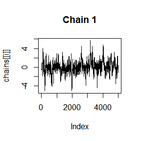

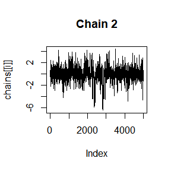

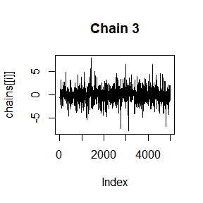

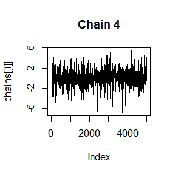

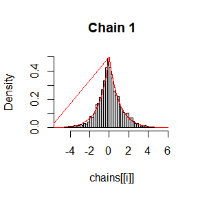

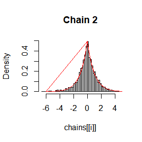

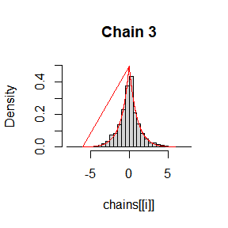

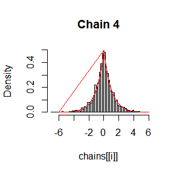

Chains with moderate proposal variances (e.g., $\sigma = 1$ and $\sigma = 2$) exhibited good convergence and acceptance rates. This highlights the importance of selecting an appropriate variance for the proposal distribution in Metropolis-Hastings algorithms.

## Question 3

## Answer 3

$$K(r, s) = I(s \neq r) \, \alpha(r, s) \, g(s | r) + I(s = r) \left[ 1 -
\int \alpha(r, s') \, g(s' | r) \, ds' \right]$$

$$K(s, r) = I(s \neq r) \, \alpha(s, r) \, g(r | s) + I(s = r) \left[ 1 -
\int \alpha(s, r') \, g(r' | s) \, dr' \right]$$

1. $s \neq r$: For $s \neq r$, the transition kernel becomes:

$$K(r, s) = \alpha(r, s) \, g(s | r)
\quad \text{and} \quad K(s, r) = \alpha(s, r) \, g(r | s)$$

$$K(s, r) f(s) = \alpha(s, r) \, g(r | s) \, f(s)$$

$$K(r, s) f(r) = \alpha(r, s) \, g(s | r) \, f(r)$$

$$\alpha(s, r) = \min\left\{ \frac{f(r) \, g(s | r)}{f(s) \, g(r | s)}, 1
\right\}$$

$$\alpha(r, s) = \min\left\{ \frac{f(s) \, g(r | s)}{f(r) \, g(s | r)}, 1
\right\}$$

Notice that:

$$\alpha(s, r) \, f(s) \, g(r | s) = \alpha(r, s) \, f(r) \, g(s | r)$$

because the minimum function ensures symmetry. Hence, for $s \neq r$, we have:

$$K(s, r) f(s) = K(r, s) f(r).$$

2. $s = r$: For $s = r$, the kernels simplify to:

$$K(r, r) = 1 - \int \alpha(r, s') \, g(s' | r) \, ds'$$

and

$$K(s, s) = 1 - \int \alpha(s, r') \, g(r' | s) \, dr'.$$

Since the integrals are the same, we have:

$$K(s, s) f(s) = K(r, r) f(r).$$

# HW 7-th

## Question 1 (11.3)

1. Write a function to compute the k-th term in
   $$\sum_{k=0}^\infty\frac{(-1)^k}{k!
   2^k}\frac{\left\|a\right\|^{2k+2}}{(2k+1)(2k+2)}\frac{\Gamma\left(\frac{d+1}{2}\right)\Gamma\left(k+\frac{3}{2}\right)}{\Gamma\left(k+\frac{d}{2}+1\right)},$$
   where $d \geq 1$ is an integer, $a$ is a vector in $\mathbb{R}^d$, and $∥ · ∥$ denotes the Euclidean norm. Perform the arithmetic so that the coefficients can be computed for (almost) arbitrarily large $k$ and $d$. (This sum converges for all $a\in\mathbb{R}^d$).
2. Modify the function so that it computes and returns the sum.
3. Evaluate the sum when $a = (1, 2)^T$.

## Answer 1 (11.3)

### 1. Data Generation

```r
generate_data <- function(a) {
  # Ensure `a` is a numeric vector
  stopifnot(is.numeric(a))

  # Compute the Euclidean norm squared
  norm_sq <- sum(a^2)

  # Save norm squared to disk
  saveRDS(norm_sq, file = "norm_squared.rds")

  # Return the computed norm squared
  return(norm_sq)
  rm(list = ls()) # Clear memory
}
```

### 2. Statistical Inference

In this function `compute_sum()`, we compute each term in the infinite sum up to a specified maximum index `K`. Intermediate results are saved for reproducibility and debugging purposes.

```r
compute_sum <- function(K = 60) {
  # Load the norm squared
  norm_sq <- readRDS("norm_squared.rds")

  # Initialize required parameters
  k <- 0:K
  d <- length(a)

  # Logarithmic calculations for stability with large k and d
  log.ak <- (k + 1) * log(norm_sq)
  log.ck <- lgamma((d + 1) / 2) + lgamma(k + 1.5) - lgamma(k + 1) -
            k * log(2) - log((2 * k + 1) * (2 * k + 2)) - lgamma(k + d / 2 + 1)

  # Compute each term in the sum
  y <- exp(log.ak + log.ck)
  i <- rep(c(1, -1), length = K + 1)
  result <- sqrt(2 / pi) * sum(i * y)

  # Save results
  saveRDS(result, file = "sum_result.rds")

  # Return the result
  return(result)
  rm(list = ls()) # Clear memory
}
```

### 3. Result Reporting

The final function `report_results()` loads and reports the computed sum, comparing the result with an approximation for very large $\|a\|$ as verification step.

```r
report_results <- function() {
  # Load the computed result
  sum_result <- readRDS("sum_result.rds")

  # Load the norm squared
  norm_sq <- readRDS("norm_squared.rds")

  # Report the result
  cat("Computed sum:", sum_result, "\n")

  # Approximation for large norm values
  approx_result <- sqrt(norm_sq)
  cat("Approximation (for large norm):", approx_result, "\n")

  # Final result (taking the minimum for stability)
  final_result <- min(sum_result, approx_result)
  cat("Final reported result:", final_result)

  return(final_result)
  rm(list = ls()) # Clear memory
}
```

## Example Execution

To demonstrate the entire process, we use $a = (1, 2)^T$.

```r
# Step 1: Data Generation
a <- c(1, 2)
generate_data(a)
```

```
## [1] 5
```

```r
# Step 2: Statistical Inference
compute_sum(K = 60)
```

```
## [1] 1.22249
```

```r
# Step 3: Result Reporting
report_results()
```

```
## Computed sum: 1.22249
## Approximation (for large norm): 2.236068
## Final reported result: 1.22249
```

```
## [1] 1.22249
```

## Question 2 (11.5)

Write a function to solve the equation
$$\begin{aligned}\frac{2\Gamma(\frac{k}{2})}{\sqrt{\pi(k-1)}\Gamma(\frac{k-1}{2})}&\int_0^{c_{k-1}}\left(1+\frac{u^2}{k-1}\right)^{-k/2}du\\&=\frac{2\Gamma(\frac{k+1}2)}{\sqrt{\pi
k}\Gamma(\frac
k2)}\int_0^{c_k}\left(1+\frac{u^2}k\right)^{-(k+1)/2}du\end{aligned}$$

for $a$, where
$$c_k=\sqrt{\frac{a^2k}{k+1-a^2}}.$$
Compare the solutions with the points $A(k)$ in Exercise 11.4.

## Answer 2 (11.5)

We can solve this equation by observing that each side represents the cumulative distribution function (CDF) of a Student’s $t$-distribution with degrees of freedom $k-1$ and $k$ respectively. This setup enables us to find $a$ by evaluating the differences between the CDFs for varying values of $k$.

### 1. Data Generation

The `generate_data()` function initializes the values of $k$ and the range of $a$ values for calculating differences in the CDFs.

```r
generate_data <- function() {
  # Define the range of values for k
  K <- c(4:25, 100, 500, 1000)

  # Initial values of a are set to a range for evaluation
  a <- seq(1, sqrt(max(K)) - 0.01, length = 100)

  # Save initial data for reuse
  saveRDS(list(K = K, a = a), file = "data_params.rds")

  # Return generated data
  return(list(K = K, a = a))
  rm(list = ls()) # Clear memory
}
```

### 2. Statistical Inference

```r
solve_for_ck <- function() {
  # Load initial data
  data_params <- readRDS("data_params.rds")
  K <- data_params$K
  a_vals <- data_params$a

  # Define helper function to compute CDF difference
  cdf_difference <- function(a, k) {
    c1 <- sqrt(a^2 * (k - 1) / (k - a^2))
    c2 <- sqrt(a^2 * k / (k + 1 - a^2))
    p1 <- pt(c1, df = k - 1, lower.tail = FALSE)
    p2 <- pt(c2, df = k, lower.tail = FALSE)
    p1 - p2
  }

  # Initialize storage for results
  a_values <- numeric(length(K))
  pr_values <- numeric(length(K))

  # Calculate r values by finding roots where CDF difference is zero
  for (i in seq_along(K)) {
    k <- K[i]
    # Solve for r using uniroot on CDF difference function
    root <- uniroot(cdf_difference, lower = 1, upper = 2, k = k)
    a_values[i] <- root$root
  }

  # Calculate c_k based on given formula
  ck <- sqrt(a_values^2 * K / (K + 1 - a_values^2))

  # Save c_k results to disk for reporting
  saveRDS(ck, file = "ck_results.rds")

  # Save results for reporting
  saveRDS(list(K = K, a = a_values), file = "data_params.rds")

  # Return computed values
  return(data.frame(K = K, a = a_values, ck = ck))
  rm(list = ls()) # Clear memory
}
```

### 3. Result Reporting

The `report_results()` function loads the calculated results and displays them in a table format for comparison.

```r
report_results <- function() {
  # Load computed c_k values
  ck <- readRDS("ck_results.rds")

  # Load original data for reference points
  data_params <- readRDS("data_params.rds")
  K <- data_params$K
  a <- data_params$a

  # Combine results for display
  results <- cbind(K, a, ck)
  print("Computed results for ck:")
  print(results)

  # Return results for further analysis if needed
  return(results)
  rm(list = ls()) # Clear memory
}
```

```r
# Step 1: Data Generation
generate_data()
```

```
## $K
##  [1]    4    5    6    7    8    9   10   11   12   13   14   15   16   17   18
## [16]   19   20   21   22   23   24   25  100  500 1000
##
## $a
##   [1]  1.000000  1.309220  1.618440  1.927660  2.236880  2.546100  2.855320
##   [8]  3.164540  3.473760  3.782980  4.092200  4.401420  4.710640  5.019860
##  [15]  5.329080  5.638299  5.947519  6.256739  6.565959  6.875179  7.184399
##  [22]  7.493619  7.802839  8.112059  8.421279  8.730499  9.039719  9.348939
##  [29]  9.658159  9.967379 10.276599 10.585819 10.895039 11.204259 11.513479
##  [36] 11.822699 12.131919 12.441139 12.750359 13.059579 13.368799 13.678019
##  [43] 13.987239 14.296459 14.605678 14.914898 15.224118 15.533338 15.842558
##  [50] 16.151778 16.460998 16.770218 17.079438 17.388658 17.697878 18.007098
##  [57] 18.316318 18.625538 18.934758 19.243978 19.553198 19.862418 20.171638
##  [64] 20.480858 20.790078 21.099298 21.408518 21.717738 22.026958 22.336178
##  [71] 22.645398 22.954618 23.263838 23.573057 23.882277 24.191497 24.500717
##  [78] 24.809937 25.119157 25.428377 25.737597 26.046817 26.356037 26.665257
##  [85] 26.974477 27.283697 27.592917 27.902137 28.211357 28.520577 28.829797
##  [92] 29.139017 29.448237 29.757457 30.066677 30.375897 30.685117 30.994337
##  [99] 31.303557 31.612777
```

```r
# Step 2: Statistical Inference
solve_for_ck()
```

```
##       K        a       ck
## 1     4 1.492103 1.791862
## 2     5 1.533556 1.795334
## 3     6 1.562744 1.793016
## 4     7 1.584430 1.789174
## 5     8 1.601185 1.785136
## 6     9 1.614521 1.781334
## 7    10 1.625390 1.777885
## 8    11 1.634419 1.774801
## 9    12 1.642038 1.772054
## 10   13 1.648554 1.769606
## 11   14 1.654190 1.767419
## 12   15 1.659114 1.765459
## 13   16 1.663452 1.763694
## 14   17 1.667303 1.762099
## 15   18 1.670745 1.760652
## 16   19 1.673840 1.759335
## 17   20 1.676637 1.758130
## 18   21 1.679178 1.757025
## 19   22 1.681496 1.756009
## 20   23 1.683620 1.755070
## 21   24 1.685572 1.754201
## 22   25 1.687373 1.753395
## 23  100 1.720608 1.737726
## 24  500 1.729755 1.733212
## 25 1000 1.730907 1.732638
```

```r
# Step 3: Result Reporting
report_results()
```

```
## [1] "Computed results for ck:"
##          K        a       ck
##  [1,]    4 1.492103 1.791862
##  [2,]    5 1.533556 1.795334
##  [3,]    6 1.562744 1.793016
##  [4,]    7 1.584430 1.789174
##  [5,]    8 1.601185 1.785136
##  [6,]    9 1.614521 1.781334
##  [7,]   10 1.625390 1.777885
##  [8,]   11 1.634419 1.774801
##  [9,]   12 1.642038 1.772054
## [10,]   13 1.648554 1.769606
## [11,]   14 1.654190 1.767419
## [12,]   15 1.659114 1.765459
## [13,]   16 1.663452 1.763694
## [14,]   17 1.667303 1.762099
## [15,]   18 1.670745 1.760652
## [16,]   19 1.673840 1.759335
## [17,]   20 1.676637 1.758130
## [18,]   21 1.679178 1.757025
## [19,]   22 1.681496 1.756009
## [20,]   23 1.683620 1.755070
## [21,]   24 1.685572 1.754201
## [22,]   25 1.687373 1.753395
## [23,]  100 1.720608 1.737726
## [24,]  500 1.729755 1.733212
## [25,] 1000 1.730907 1.732638
```

```
##          K        a       ck
##  [1,]    4 1.492103 1.791862
##  [2,]    5 1.533556 1.795334
##  [3,]    6 1.562744 1.793016
##  [4,]    7 1.584430 1.789174
##  [5,]    8 1.601185 1.785136
##  [6,]    9 1.614521 1.781334
##  [7,]   10 1.625390 1.777885
##  [8,]   11 1.634419 1.774801
##  [9,]   12 1.642038 1.772054
## [10,]   13 1.648554 1.769606
## [11,]   14 1.654190 1.767419
## [12,]   15 1.659114 1.765459
## [13,]   16 1.663452 1.763694
## [14,]   17 1.667303 1.762099
## [15,]   18 1.670745 1.760652
## [16,]   19 1.673840 1.759335
## [17,]   20 1.676637 1.758130
## [18,]   21 1.679178 1.757025
## [19,]   22 1.681496 1.756009
## [20,]   23 1.683620 1.755070
## [21,]   24 1.685572 1.754201
## [22,]   25 1.687373 1.753395
## [23,]  100 1.720608 1.737726
## [24,]  500 1.729755 1.733212
## [25,] 1000 1.730907 1.732638
```

## Question 3

Suppose $T_{1}, \dots, T_{n}$ are i.i.d. samples drawn from the exponential distribution with expectation $\lambda$. Those values greater than $\tau$ are not observed due to right censorship, so that the observed values are $Y_{i} = T_{i}I(T_{i} \leq \tau) + \tau I(T_{i} > \tau), i = 1,\dots, n$. Suppose $\tau = 1$ and the observed $Y_i$ values are as follows:
$$0.54, 0.48, 0.33, 0.43, 1.00, 1.00, 0.91, 1.00, 0.21, 0.85$$
Use the E-M algorithm to estimate $\lambda$, compare your result with the observed data MLE (note: $Y_{i}$ follows a mixture distribution).

## Answer 3

### 1. Data Generation

The `generate_data()` function prepares the observed data and defines initial values for the parameter estimation.

```r
generate_data <- function() {
  # Observed censored data
  Y <- c(0.54, 0.48, 0.33, 0.43, 1.00, 1.00, 0.91, 1.00, 0.21, 0.85)

  # Censoring threshold
  tau <- 1

  # Save initial data to disk
  saveRDS(list(Y = Y, tau = tau), file = "data_params.rds")

  # Return data for verification
  return(list(Y = Y, tau = tau))
  rm(list = ls()) # Clear memory
}
```

### 2. Statistical Inference

The `estimate_lambda_em()` function applies the EM algorithm to estimate $\lambda$ from censored data. The expectation step (E-step) calculates the expected values of the censored observations, and the maximization step (M-step) updates the estimate of $\lambda$.

```r
estimate_lambda_em <- function(tol = 1e-6, max_iter = 1000) {
  # Load data parameters
  data_params <- readRDS("data_params.rds")
  Y <- data_params$Y
  tau <- data_params$tau

  # Initialize lambda with the mean of the observed data
  lambda <- mean(Y)

  # Track convergence
  iter <- 0
  diff <- tol + 1

  # EM Algorithm
  while (diff > tol && iter < max_iter) {
    # E-step: Estimate the expected values for censored observations
    uncensored_Y <- Y[Y < tau]
    censored_Y <- Y[Y >= tau]
    n_uncensored <- length(uncensored_Y)
    n_censored <- length(censored_Y)

    # Expected total time for censored observations
    E_censored_sum <- n_censored * (tau + 1/lambda)

    # M-step: Update lambda
    lambda_new <- (sum(uncensored_Y) + E_censored_sum) / length(Y)

    # Check for convergence
    diff <- abs(lambda_new - lambda)
    lambda <- lambda_new
    iter <- iter + 1
  }

  # Save final estimate to disk for reporting
  saveRDS(list(lambda = lambda, iter = iter, diff = diff), file = "estimate_results.rds")

  # Return the final estimate for verification
  return(list(lambda = lambda, iter = iter, diff = diff))
  rm(list = ls()) # Clear memory
}
```

### 3. Result Reporting

The `report_results()` function compares the EM estimate of $\lambda$ with the MLE from observed data, displaying results and convergence information.

```r
report_results <- function() {
  # Load EM estimate results
  estimate_results <- readRDS("estimate_results.rds")
  lambda_em <- estimate_results$lambda
  iter <- estimate_results$iter
  diff <- estimate_results$diff

  # Observed MLE of lambda using uncensored data only
  data_params <- readRDS("data_params.rds")
  Y <- data_params$Y
  tau <- data_params$tau
  uncensored_Y <- Y[Y < tau]
  lambda_mle <- mean(uncensored_Y)

  # Display the results
  cat("EM Algorithm Estimation of lambda:\n")
  cat(" - Lambda Estimate (EM):", lambda_em, "\n")
  cat(" - Iterations:", iter, "\n")
  cat(" - Final Convergence Difference:", diff, "\n\n")

  cat("Observed Data MLE of lambda (using uncensored values only):", lambda_mle, "\n")

  # Plot the estimates for visual comparison
  barplot(c(lambda_em, lambda_mle), beside = TRUE, names.arg = c("EM Estimate", "MLE"),
          col = c("blue", "red"), main = "Comparison of Lambda Estimates",
          ylab = "Lambda Estimate")

  # Return results for further use if needed
  return(list(lambda_em = lambda_em, lambda_mle = lambda_mle))
  rm(list = ls()) # Clear memory
}
```

```r
# Step 1: Generate data
generate_data()
```

```
## $Y
##  [1] 0.54 0.48 0.33 0.43 1.00 1.00 0.91 1.00 0.21 0.85
##
## $tau
## [1] 1
```

```r
# Step 2: Estimate lambda using EM algorithm
estimate_lambda_em()
```

```
## $lambda
## [1] 0.9808556
##
## $iter
## [1] 13
##
## $diff
## [1] 4.44839e-07
```

```r
# Step 3: Report and visualize results
report_results()
```

```
## EM Algorithm Estimation of lambda:
##  - Lambda Estimate (EM): 0.9808556
##  - Iterations: 13
##  - Final Convergence Difference: 4.44839e-07
##
## Observed Data MLE of lambda (using uncensored values only): 0.5357143
```

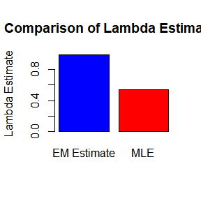

```
## $lambda_em
## [1] 0.9808556
##
## $lambda_mle
## [1] 0.5357143
```